# Syrian Civil War Refugee and Host Country Characteristics

# Overview

Video Link: https://www.youtube.com/watch?v=_cVRzEtX0ho

The Syrian Civil War has caused a large outflow of refugees into countries all over the world. Especially notable are the host nations bordering the country who hold the most refugees from this internal conflict. To figure out the basic demographics of the Syrian refugee population, we performed basic data processing and visualization tasks. As for determining significant measures that Syrian refugees may take a look at when settling in a host country, we applied a linear regression and correlation analysis to determine which features strongly correlate with a higher refugee population count. With about 5.6 million Syrian refugees in the countries neighboring Syria, most of them being male, we found that a large portion of them were minors who make up 46% of the male refugee population and 48% of the female refugee population. With four nations to pick from, we found that nations who were a signatory of the 1951 Refugee Convention, had a higher population size, had a higher Gross Domestic Product (GDP), and had higher rates of kidnapping were highly associated with taking in more refugees whereas nations who had more events in terms of fatalities, explosions/remote violence and battles had a strong negative correlation with refugee influx into a country.

# Names

- Yeon Suh
- Ryan Kao
- Russell Zuchlewski
- Kevin Nguyen
- Connor Bates

# Research Question

What internal demographic differences and events are present among displaced Syrian refugees and the nations where they flee? Are there any apparent trends among refugee and asylum seekers’ migration to bordering nations?

# Background & Prior Work

In the modern socio-political climate refugee and asylum seekers comprise one of the most vulnerable and one of the fastest growing populations. A 2021 study of refugee and asylum seekers by the United Nations indicated that a record number 84 million refugees had been displaced in the time period between January 2021 and November 2021 [^UN2]. Current projections show the effects of climate change, the COVID-19 Pandemic and governmental instability exacerbating this already growing trend throughout the 2020s. Understanding refugee patterns and the taken towards resettlement is key to being properly prepared and integrating them into host countries. Representing the largest and longest refugee crisis of the 2010s, an analysis of refugee data from the Syrian Civil War can provide insights on how governments and NGOs can better prepare for future global crises.

Following the most intense drought in modern Syrian history from 2006 to 2010, the largely agrarian population had resettled into urban ghettos. Following the period of resettlement, disturbed populations began to protest inequitable economic policy as well as the complacent Assad regime [^Brit]. Military response to the peaceful protests seen throughout the region sparked what has become a decade long civil war for control of Syria. The Civil War has seen over 6.6 million registered Syrian refugees leave the country [^UN].

References: [^Brit]: Britannica, The Editors of Encyclopaedia. "Syrian Civil War". *Encyclopedia Britannica*, 17 Jul. 2020, https://www.britannica.com/event/Syrian-Civil-War. Accessed 21 April 2022. [^UN]: “Syria Refugee Crisis Explained.” How to Help Refugees - Aid, Relief and Donations, 2021, https://www.unrefugees.org/news/syria-refugee-crisis-explained/#What%20is%20happening%20in%20Syria%E2%80%99s%20northwest%20region%20%E2%80%93%C2%A0specifically%20in%20Idlib%C2%A0%E2%80%93%C2%A0right%20now? [^UN2]: “2021 Year in Review: Refugee, Migrant Numbers Rise, despite Travel Curbs | | UN News.” United Nations, United Nations, 2021, https://www.news.un.org/en/story/2021/12/1108472.

# Hypothesis

Our team believes that refugees of the Syrian civil war will be skewed towards women, children, and the elderly. We believe that conscription and pressure to volunteer will result in men ages 18-35 remaining in the country. Furthermore we believe that politically calm and more stable nations will attract more refugees than other nations. While they are ultimately looking to flee from prosecution to relative safety, social programs and political stability will attract refugees.

# Dataset(s)

**Dataset names:**

Total Persons of Concern by Country of Asylum

Population of Syrian Refugees

**Dataset link:**

https://data2.unhcr.org/en/situations/syria

**Description of dataset:**

These datasets include the total number of Syrian refugees per country of asylum and the populations of refugees based on gender and age.

**Number of observations:**

6 & 1 *note: we arrange the dataframe so that the data is more organized and more usable*

**Dataset name:**

ACLED - Country Violence and Protest Events

**Dataset link:**

https://acleddata.com/dashboard/#/dashboard

**Description of dataset:**

This dataset includes data based on the number of riots, protests, and violent events that occur in different bordering countries to Syria.

**Number of observations:**

173716

**Dataset Name:**

International Database: World Population Estimates and Projections

**Link to the dataset:**

https://www.census.gov/programs-surveys/international-programs/about/idb.html

**Number of observations:**

4

This dataset contains population counts for each specific country.

**Dataset Name:**

Demographic and socio-economic : Socio-economic indicators

**Link to the dataset:**

http://data.uis.unesco.org/#

**Number of observations:**

74

This dataset contains economic information about each individual country pertaining to Gross Domestic Product (GDP), Purchasing Power Parity (PPP), and other socio-economic indicators.

**Dataset Name:**

Unemployment, total (% of total labor force) (modeled ILO estimate) - Turkey, Iraq, Jordan, Lebanon

**Link to the dataset:**

https://data.worldbank.org/indicator/SL.UEM.TOTL.ZS?locations=TR-IQ-JO-LB

**Number of observations:**

266

This dataset contains the unemployment rates as a percentage of the total labor force for each country. It uses the ILO model estimate to calculate these numbers.

**Dataset Name:**

Inflation, consumer prices (annual %) - Turkey, Iraq, Jordan, Lebanon

**Link to the dataset:**

https://data.worldbank.org/indicator/FP.CPI.TOTL.ZG?locations=TR-IQ-JO-LB

**Number of observations:**

266

This dataset contains the annual rate of inflation for each country.

**Dataset Name:**

Kidnapping

**Link to the dataset:**

https://dataunodc.un.org/data/crime/kidnapping

**Number of observations:**

2854

This dataset reports kidnapping data per 100,000 people by country, region, year, both counts and rates.

**Dataset Name:**

Intentional homicides (per 100,000 people) - Turkey, Iraq, Jordan, Lebanon

**Link to the dataset:**

https://data.worldbank.org/indicator/VC.IHR.PSRC.P5?locations=TR-IQ-JO-LB

**Number of observations:**

266

This dataset contains information about the intentional homicides per every 100,000 people of countries across the world. These rates are presented on a yearly basis.

**Dataset Name:**

Population by Age Group - Male

Population by Age Group - Female

**Link to the dataset:**

https://population.un.org/wpp/Download/Standard/Population/

**Number of observations:**

3825

These two datasets contain information about each specific gender broken up by age groups by every 0th to 5th and 6th to 9th.

**Dataset name:**

UNHCR - Refugee Population Data

**Dataset link:**

https://popstats.unhcr.org/refugee-statistics/download/?url=nJ7D7S#_ga=2.131280207.1123456472.1654557593-125168000.1654557593

**Description of dataset:**

A data set documenting the yearly changes in refugee and asylum seeking peoples. The data was specifically controlled for populations originating out of Syria.

**Number of observations:**

**Note: Because there is no way to join some of these datasets, we plan to do separate analyses based on the different datasets that are not able to be combined.**

# Setup

```python
import numpy as np
import pandas as pd
import seaborn as sns
import matplotlib.pyplot as plt
import sklearn

from functools import reduce
from matplotlib import rcParams
from matplotlib.ticker import MaxNLocator
from sklearn.linear_model import LinearRegression
from sklearn.metrics import r2_score, mean_squared_error
from sklearn.model_selection import train_test_split
```

# Data Cleaning

For the dataset that includes the total persons of concern by country of asylum, the site that we pulled the data from did not have an accessible csv file. Because of this, we had to access the data as JSON and then use a JSON to csv converter, where we were then able to download and load in the data. Similarly to the data we obtained from ACLED, there were many columns that were not necessary for our analysis, so we created a subset of the dataframe which reduced it from 78 columns to 2. Following that, we dropped the observations for Egypt and other countries including North Africa as they are not bordering Syria. Lastly, we added a new column to this dataframe called "Benefits", referring to the legal framework available for Syrian Refugees to obtain citizenship and other benefits in these countries. We obtained this data by looking into which countries were signatories of the 1951 Refugee Convention which is a legal system on refugee rights. We quantified the legal framework by assigning the value of 1 to countries that were signatories, and 0 to countries that were not.

Furthermore, the dataset that includes the different age groups and genders was also pulled from data2 which did not have an accessible csv file, so we once again used a converter. When we loaded in the data, we noticed that there was only 1 row and 109 columns. Because the data was formatted like this, we rearranged the data so that Male and Female were the observations (rows), and the different age groups were the columns. We also dropped the unnecessary columns. The column names were not easy to read, so we renamed them to make them more intuitive. Lastly, we took the totals among the rows and created a new column with the total values.

```python
# read in events data
Events = pd.read_csv("Data Files/2011-03-15-2022-05-04-Middle_East-Iraq-Jordan-Lebanon-Syria-Turkey.csv")

# check the first 5 rows
Events.head()
```

|  | data_id | iso | event_id_cnty | event_id_no_cnty | event_date | year | time_precision | event_type | sub_event_type | actor1 | ... | location | latitude | longitude | geo_precision | source | source_scale | notes | fatalities | timestamp | iso3 |
| --- | --- | --- | --- | --- | --- | --- | --- | --- | --- | --- | --- | --- | --- | --- | --- | --- | --- | --- | --- | --- | --- |
| 0 | 9151476 | 400 | JOR965 | 965.0 | 22 April 2022 | 2022 | 1 | Protests | Peaceful protest | Protesters (Jordan) | ... | Amman | 31.9552 | 35.9450 | 1 | Jo 24; Al Ghad (Jordan) | National | On 22 April 2022, hundreds of protesters gathe... | 0 | 1650904164 | JOR |
| 1 | 9151477 | 400 | JOR966 | 966.0 | 22 April 2022 | 2022 | 1 | Protests | Peaceful protest | Protesters (Jordan) | ... | Irbid | 32.5556 | 35.8500 | 1 | Amman Net; Al Ghad (Jordan) | National | On 22 April 2022, protesters gathered for a ma... | 0 | 1650904164 | JOR |
| 2 | 9151478 | 400 | JOR967 | 967.0 | 22 April 2022 | 2022 | 1 | Protests | Peaceful protest | Protesters (Jordan) | ... | Zarqa | 32.0728 | 36.0880 | 1 | Al Ghad (Jordan); Amman Net | National | On 22 April 2022, protesters gathered for a ma... | 0 | 1650904164 | JOR |
| 3 | 9151564 | 792 | TUR24664 | 24664.0 | 22 April 2022 | 2022 | 2 | Strategic developments | Looting/property destruction | Military Forces of Turkey (2016-) Gendarmerie | ... | Tunceli | 39.0992 | 39.5435 | 2 | Ihlas News Agency; Aydinlik | National | Property destruction: Around 22 April 2022 (as... | 0 | 1650904164 | TUR |
| 4 | 9151565 | 792 | TUR24665 | 24665.0 | 22 April 2022 | 2022 | 1 | Battles | Armed clash | Military Forces of Turkey (2016-) Gendarmerie | ... | Kavakli | 37.5135 | 43.3845 | 2 | Ihlas News Agency; Haber 7 | National | On 22 April 2022, 3 PKK militants were killed ... | 3 | 1650904164 | TUR |

5 rows × 31 columns

```python
# checks dimensions of dataset
Events.shape
```

```
(173716, 31)
```

```python
# check column names
Events.columns
```

```
Index(['data_id', 'iso', 'event_id_cnty', 'event_id_no_cnty', 'event_date',
       'year', 'time_precision', 'event_type', 'sub_event_type', 'actor1',
       'assoc_actor_1', 'inter1', 'actor2', 'assoc_actor_2', 'inter2',
       'interaction', 'region', 'country', 'admin1', 'admin2', 'admin3',
       'location', 'latitude', 'longitude', 'geo_precision', 'source',
       'source_scale', 'notes', 'fatalities', 'timestamp', 'iso3'],
      dtype='object')
```

```python
events_fatalities = Events[Events.country != "Syria"]
events_fatalities = events_fatalities.groupby(['country', 'year']).sum().reset_index()
events_fatalities = events_fatalities[['country', 'year', 'fatalities']]
events_fatalities
```

|  | country | year | fatalities |
| --- | --- | --- | --- |
| 0 | Iraq | 2016 | 56335 |
| 1 | Iraq | 2017 | 32027 |
| 2 | Iraq | 2018 | 5621 |
| 3 | Iraq | 2019 | 3718 |
| 4 | Iraq | 2020 | 2805 |
| 5 | Iraq | 2021 | 2753 |
| 6 | Iraq | 2022 | 610 |
| 7 | Jordan | 2016 | 65 |
| 8 | Jordan | 2017 | 35 |
| 9 | Jordan | 2018 | 6 |
| 10 | Jordan | 2019 | 6 |
| 11 | Jordan | 2020 | 7 |
| 12 | Jordan | 2021 | 0 |
| 13 | Jordan | 2022 | 0 |
| 14 | Lebanon | 2016 | 221 |
| 15 | Lebanon | 2017 | 389 |
| 16 | Lebanon | 2018 | 36 |
| 17 | Lebanon | 2019 | 25 |
| 18 | Lebanon | 2020 | 48 |
| 19 | Lebanon | 2021 | 73 |
| 20 | Lebanon | 2022 | 5 |
| 21 | Turkey | 2016 | 5201 |
| 22 | Turkey | 2017 | 2917 |
| 23 | Turkey | 2018 | 1951 |
| 24 | Turkey | 2019 | 961 |
| 25 | Turkey | 2020 | 554 |
| 26 | Turkey | 2021 | 302 |
| 27 | Turkey | 2022 | 31 |

```python
# created subset of dataframe, removing all unnecessary columns
Events = Events[["event_type", "country", "fatalities"]]
```

```python
# removing Syria
Events = Events[Events.country != "Syria"]
```

```python
# count of total events
total_events = Events.loc[:, Events.columns!='fatalities'].groupby('country').count()
total_events.index.name = 'country'
total_events.reset_index(inplace=True)
total_events
```

|  | country | event_type |
| --- | --- | --- |
| 0 | Iraq | 37053 |
| 1 | Jordan | 940 |
| 2 | Lebanon | 12442 |
| 3 | Turkey | 24726 |

```python
# rename columns
total_events.columns = ['country', 'event_counts']
total_events
```

|  | country | event_counts |
| --- | --- | --- |
| 0 | Iraq | 37053 |
| 1 | Jordan | 940 |
| 2 | Lebanon | 12442 |
| 3 | Turkey | 24726 |

```python
# count of total fatalities
total_fatalities = Events.loc[:, Events.columns!='event_type'].groupby('country').agg('sum')
total_fatalities.index.name = 'country'
total_fatalities.reset_index(inplace=True)
total_fatalities
```

|  | country | fatalities |
| --- | --- | --- |
| 0 | Iraq | 103869 |
| 1 | Jordan | 119 |
| 2 | Lebanon | 797 |
| 3 | Turkey | 11917 |

```python
# rename columns
total_fatalities.columns = ['country', 'total_fatalities']
total_fatalities
```

|  | country | total_fatalities |
| --- | --- | --- |
| 0 | Iraq | 103869 |
| 1 | Jordan | 119 |
| 2 | Lebanon | 797 |
| 3 | Turkey | 11917 |

```python
# count of each event_type per country
count_event = Events.groupby(['country', 'event_type']).count().reset_index()
count_event = count_event.pivot(index = 'country', columns = 'event_type', values = 'fatalities')
count_event.index.name = 'country'
count_event.reset_index(inplace=True)
count_event
```

| event_type | country | Battles | Explosions/Remote violence | Protests | Riots | Strategic developments | Violence against civilians |
| --- | --- | --- | --- | --- | --- | --- | --- |
| 0 | Iraq | 8413 | 17263 | 4936 | 1074 | 3091 | 2276 |
| 1 | Jordan | 17 | 21 | 726 | 89 | 76 | 11 |
| 2 | Lebanon | 502 | 295 | 8765 | 2265 | 403 | 212 |
| 3 | Turkey | 3268 | 1470 | 14511 | 356 | 4381 | 740 |

```python
# rename columns
count_event.columns = ['country', 'battles', 'explosions_remote_violence', 'protests', 'riots', 'strategic_developments', 'violence_against_civilians']
count_event
```

|  | country | battles | explosions_remote_violence | protests | riots | strategic_developments | violence_against_civilians |
| --- | --- | --- | --- | --- | --- | --- | --- |
| 0 | Iraq | 8413 | 17263 | 4936 | 1074 | 3091 | 2276 |
| 1 | Jordan | 17 | 21 | 726 | 89 | 76 | 11 |
| 2 | Lebanon | 502 | 295 | 8765 | 2265 | 403 | 212 |
| 3 | Turkey | 3268 | 1470 | 14511 | 356 | 4381 | 740 |

```python
# count of each fatality per event_type per country
fatality_event = Events.groupby(['country', 'event_type']).agg('sum').reset_index()
fatality_event = fatality_event.pivot(index = 'country', columns = 'event_type', values = 'fatalities')
fatality_event.index.name = 'country'
fatality_event.reset_index(inplace=True)
fatality_event
```

| event_type | country | Battles | Explosions/Remote violence | Protests | Riots | Strategic developments | Violence against civilians |
| --- | --- | --- | --- | --- | --- | --- | --- |
| 0 | Iraq | 47616 | 45343 | 141 | 526 | 385 | 9858 |
| 1 | Jordan | 61 | 44 | 0 | 3 | 5 | 6 |
| 2 | Lebanon | 534 | 135 | 1 | 19 | 46 | 62 |
| 3 | Turkey | 9000 | 2512 | 5 | 10 | 34 | 356 |

```python
# rename columns
fatality_event.columns = ['country', 'fatalities_battles', 'fatalities_explosions_remote_violence', 'fatalities_protests', 'fatalities_riots', 'fatalities_strategic_developments', 'fatalities_violence_against_civilians']
fatality_event
```

|  | country | fatalities_battles | fatalities_explosions_remote_violence | fatalities_protests | fatalities_riots | fatalities_strategic_developments | fatalities_violence_against_civilians |
| --- | --- | --- | --- | --- | --- | --- | --- |
| 0 | Iraq | 47616 | 45343 | 141 | 526 | 385 | 9858 |
| 1 | Jordan | 61 | 44 | 0 | 3 | 5 | 6 |
| 2 | Lebanon | 534 | 135 | 1 | 19 | 46 | 62 |
| 3 | Turkey | 9000 | 2512 | 5 | 10 | 34 | 356 |

```python
# read in total population data
count_refugees = pd.read_csv("Data Files/totalpopulation.csv")
count_refugees
```

|  | geomaster_name | geomaster_id | admin_level | centroid_lon | centroid_lat | lat_max | lon_max | lat_min | lon_min | source | ... | population_groups/3/pop_data_type_code | population_groups/3/pop_data_type_name | population_groups/3/pop_type_code | population_groups/3/pop_type_name | population_groups/3/pop_frequency_name | population_groups/3/pop_frequency_code | population_groups/3/pop_frequency_cumulative | population_groups/3/pop_frequency_cumulative_code | population_groups/3/pop_origin_name | population_groups/3/pop_origin_code |
| --- | --- | --- | --- | --- | --- | --- | --- | --- | --- | --- | --- | --- | --- | --- | --- | --- | --- | --- | --- | --- | --- |
| 0 | Turkey | 113 | Country | 35.970216 | 39.127913 | 42.603439 | 46.661622 | 35.277401 | 25.278809 | Government of Turkey | ... | NaN | NaN | NaN | NaN | NaN | NaN | NaN | NaN | NaN | NaN |
| 1 | Lebanon | 71 | Country | 35.910882 | 33.936363 | 34.806453 | 36.846429 | 32.866357 | 34.821527 | UNHCR | ... | NaN | NaN | NaN | NaN | NaN | NaN | NaN | NaN | NaN | NaN |
| 2 | Jordan | 36 | Country | 36.788600 | 31.253900 | 33.576385 | 39.547877 | 28.985966 | 34.161159 | UNHCR | ... | REG | Registered | REF | Refugees | Daily | D | cumulative | C | Syrian Arab Rep. | SYR |
| 3 | Iraq | 5 | Country | 43.765000 | 33.056000 | 38.008065 | 48.831406 | 28.786154 | 38.171250 | UNHCR | ... | REG | Registered | REF | Refugees | Daily | D | cumulative | C | Syrian Arab Rep. | SYR |
| 4 | Egypt | 1 | Country | 30.055430 | 29.875383 | 0.000000 | 0.000000 | 0.000000 | 0.000000 | UNHCR | ... | NaN | NaN | NaN | NaN | NaN | NaN | NaN | NaN | NaN | NaN |
| 5 | Other (North Africa) | 5586 | Country | 9.977354 | 28.634992 | 33.639744 | 24.226562 | 21.220296 | 5.832031 | UNHCR | ... | NaN | NaN | NaN | NaN | NaN | NaN | NaN | NaN | NaN | NaN |

6 rows × 78 columns

```python
# checks dimensions of total population dataframe
count_refugees.shape
```

```
(6, 78)
```

```python
# checks column names
count_refugees.columns
```

```
Index(['geomaster_name', 'geomaster_id', 'admin_level', 'centroid_lon',
       'centroid_lat', 'lat_max', 'lon_max', 'lat_min', 'lon_min', 'source',
       'date', 'month', 'year', 'population_groups_concat',
       'population_group_id', 'individuals_type', 'demography_type',
       'individuals', 'households', 'population_groups/0/id',
       'population_groups/0/name',
       'population_groups/0/pop_accommodation_code',
       'population_groups/0/pop_accommodation_name',
       'population_groups/0/pop_data_type_code',
       'population_groups/0/pop_data_type_name',
       'population_groups/0/pop_type_code',
       'population_groups/0/pop_type_name',
       'population_groups/0/pop_frequency_name',
       'population_groups/0/pop_frequency_code',
       'population_groups/0/pop_frequency_cumulative',
       'population_groups/0/pop_frequency_cumulative_code',
       'population_groups/0/pop_origin_name',
       'population_groups/0/pop_origin_code', 'population_groups/1/id',
       'population_groups/1/name',
       'population_groups/1/pop_accommodation_code',
       'population_groups/1/pop_accommodation_name',
       'population_groups/1/pop_data_type_code',
       'population_groups/1/pop_data_type_name',
       'population_groups/1/pop_type_code',
       'population_groups/1/pop_type_name',
       'population_groups/1/pop_frequency_name',
       'population_groups/1/pop_frequency_code',
       'population_groups/1/pop_frequency_cumulative',
       'population_groups/1/pop_frequency_cumulative_code',
       'population_groups/1/pop_origin_name',
       'population_groups/1/pop_origin_code', 'published', 'numChildren',
       'color', 'population_groups/2/id', 'population_groups/2/name',
       'population_groups/2/pop_accommodation_code',
       'population_groups/2/pop_accommodation_name',
       'population_groups/2/pop_data_type_code',
       'population_groups/2/pop_data_type_name',
       'population_groups/2/pop_type_code',
       'population_groups/2/pop_type_name',
       'population_groups/2/pop_frequency_name',
       'population_groups/2/pop_frequency_code',
       'population_groups/2/pop_frequency_cumulative',
       'population_groups/2/pop_frequency_cumulative_code',
       'population_groups/2/pop_origin_name',
       'population_groups/2/pop_origin_code', 'population_groups/3/id',
       'population_groups/3/name',
       'population_groups/3/pop_accommodation_code',
       'population_groups/3/pop_accommodation_name',
       'population_groups/3/pop_data_type_code',
       'population_groups/3/pop_data_type_name',
       'population_groups/3/pop_type_code',
       'population_groups/3/pop_type_name',
       'population_groups/3/pop_frequency_name',
       'population_groups/3/pop_frequency_code',
       'population_groups/3/pop_frequency_cumulative',
       'population_groups/3/pop_frequency_cumulative_code',
       'population_groups/3/pop_origin_name',
       'population_groups/3/pop_origin_code'],
      dtype='object')
```

```python
# create subset of dataframe with necessary columns
count_refugees = count_refugees[["geomaster_name", "individuals"]]
count_refugees
```

|  | geomaster_name | individuals |
| --- | --- | --- |
| 0 | Turkey | 3763211 |
| 1 | Lebanon | 839086 |
| 2 | Jordan | 674458 |
| 3 | Iraq | 258965 |
| 4 | Egypt | 141303 |
| 5 | Other (North Africa) | 41742 |

```python
# remove Other(North Africa) and Egypt from dataframe as we are only looking at countries bordering Syria
count_refugees = count_refugees[count_refugees.geomaster_name != "Other (North Africa)"]
count_refugees = count_refugees[count_refugees.geomaster_name != "Egypt"]
count_refugees
```

|  | geomaster_name | individuals |
| --- | --- | --- |
| 0 | Turkey | 3763211 |
| 1 | Lebanon | 839086 |
| 2 | Jordan | 674458 |
| 3 | Iraq | 258965 |

```python
# adds "Benefits" column to dataframe. This tells whether the country is a signatory of the 1951 Refugee Convention or not.
count_refugees["Benefits"] = [1, 0, 0, 0]
count_refugees
```

|  | geomaster_name | individuals | Benefits |
| --- | --- | --- | --- |
| 0 | Turkey | 3763211 | 1 |
| 1 | Lebanon | 839086 | 0 |
| 2 | Jordan | 674458 | 0 |
| 3 | Iraq | 258965 | 0 |

```python
# renaming columns to add to large dataset later
count_refugees.columns = ['country', 'count_refugees', 'benefits']
```

```python
# read in age and gender dataset
age_and_gender = pd.read_csv("Data Files/age_and_gender.csv")
age_and_gender
```

|  | date | month | year | population_group_name | population_groups_concat | population_group_id | source | individuals | households | male_04 | ... | population_groups/5/pop_data_type_code | population_groups/5/pop_data_type_name | population_groups/5/pop_type_code | population_groups/5/pop_type_name | population_groups/5/pop_frequency_name | population_groups/5/pop_frequency_code | population_groups/5/pop_frequency_cumulative | population_groups/5/pop_frequency_cumulative_code | population_groups/5/pop_origin_name | population_groups/5/pop_origin_code |
| --- | --- | --- | --- | --- | --- | --- | --- | --- | --- | --- | --- | --- | --- | --- | --- | --- | --- | --- | --- | --- | --- |
| 0 | 2022-04-30 | 12 | 2021 | Registered refugees from Syrian Arab Republic | Registered refugees from Syrian Arab Republic,... | 4772, 4773, 4774, 4775, 4787, 4788 | UNHCR, Government of Turkey | 5724420 | 314416 | 390331 | ... | REG | Registered | REF | Refugees | Daily | D | cumulative | C | Syrian Arab Rep. | SYR |

1 rows × 109 columns

```python
# create subset of dataframe with necessary columns
age_and_gender = age_and_gender[["male_04", "male_511", "male_1217", "male_1859", "male_60",
                                 "male_total", "female_04", "female_511", "female_1217", "female_1859",
                                 "female_60", "female_total"]]
age_and_gender
```

|  | male_04 | male_511 | male_1217 | male_1859 | male_60 | male_total | female_04 | female_511 | female_1217 | female_1859 | female_60 | female_total |
| --- | --- | --- | --- | --- | --- | --- | --- | --- | --- | --- | --- | --- |
| 0 | 390331 | 568778 | 412900 | 1511855 | 86207 | 2501083 | 367001 | 538330 | 382294 | 1310985 | 100054 | 2240139 |

```python
# Rearrange dataframe so that the age groups are the columns, and Male/Female are the observations
# Adds totals to the rows and columns
age_gender_rearranged = pd.DataFrame({"Gender" : ["Male", "Female"], "Age 0 to 4" : [390331, 367001],
                                      "Age 5 to 11" : [568778, 538330], "Age 12 to 17" : [412900, 382294],
                                      "Age 18 to 59" : [1511855, 1310985], "Age 60+" : [86207, 100054]})
age_gender_rearranged["Total"] = [age_gender_rearranged.sum(axis=1)[0], age_gender_rearranged.sum(axis=1)[1]]
age_gender_rearranged
```

|  | Gender | Age 0 to 4 | Age 5 to 11 | Age 12 to 17 | Age 18 to 59 | Age 60+ | Total |
| --- | --- | --- | --- | --- | --- | --- | --- |
| 0 | Male | 390331 | 568778 | 412900 | 1511855 | 86207 | 2970071 |
| 1 | Female | 367001 | 538330 | 382294 | 1310985 | 100054 | 2698664 |

In trying to understand the different demographics and appeals of the countries who host the refugees fleeing from the Syrian Civil War, we chose to take a look at certain population characteristics including population size, annual growth rate percentage, density per square kilometer, life expectancy at birth, and the mortality rate for people under 5 years old.

```python
# read in population statistics data
pop_stats = pd.read_csv("Data Files/population_statistics.csv")

# display first 5 rows
pop_stats.head()
```

|  | Row | FIPS | GENC | Country/Area Name | Year | Population | Annual Growth Rate % | Area (sq km) | Density (per sq km) | Total Fertility Rate | Life Expectancy at Birth | Under-5 Mortality Rate |
| --- | --- | --- | --- | --- | --- | --- | --- | --- | --- | --- | --- | --- |
| 0 | 1 | IZ | IQ | Iraq | 2022 | 40462701 | 1.997 | 437367 | 92.5 | 3.246 | 73.18 | 23.49 |
| 1 | 2 | JO | JO | Jordan | 2022 | 10998531 | 0.806 | 88802 | 123.9 | 2.956 | 76.01 | 16.07 |
| 2 | 3 | LE | LB | Lebanon | 2022 | 5296814 | 0.659 | 10230 | 517.8 | 1.710 | 78.76 | 7.75 |
| 3 | 4 | TU | TR | Turkey | 2022 | 83047706 | 0.669 | 769632 | 107.9 | 1.928 | 76.21 | 22.21 |

```python
# check size
pop_stats.shape
```

```
(4, 12)
```

```python
# check column name
pop_stats.columns
```

```
Index(['Row', 'FIPS', 'GENC', 'Country/Area Name', 'Year', 'Population',
       'Annual Growth Rate %', 'Area (sq km)', 'Density (per sq km)',
       'Total Fertility Rate', 'Life Expectancy at Birth',
       'Under-5 Mortality Rate'],
      dtype='object')
```

```python
# subsetting dataset
pop_stats = pop_stats[["Country/Area Name", "Population", "Annual Growth Rate %",
                       "Density (per sq km)", "Life Expectancy at Birth",
                       "Under-5 Mortality Rate"]]
pop_stats
```

|  | Country/Area Name | Population | Annual Growth Rate % | Density (per sq km) | Life Expectancy at Birth | Under-5 Mortality Rate |
| --- | --- | --- | --- | --- | --- | --- |
| 0 | Iraq | 40462701 | 1.997 | 92.5 | 73.18 | 23.49 |
| 1 | Jordan | 10998531 | 0.806 | 123.9 | 76.01 | 16.07 |
| 2 | Lebanon | 5296814 | 0.659 | 517.8 | 78.76 | 7.75 |
| 3 | Turkey | 83047706 | 0.669 | 107.9 | 76.21 | 22.21 |

```python
# check to see if any cells have null values
pop_stats.isnull().any
```

```
<bound method NDFrame._add_numeric_operations.<locals>.any of    Country/Area Name  Population  Annual Growth Rate %  Density (per sq km)  \
0              False       False                 False                False
1              False       False                 False                False
2              False       False                 False                False
3              False       False                 False                False

   Life Expectancy at Birth  Under-5 Mortality Rate
0                     False                   False
1                     False                   False
2                     False                   False
3                     False                   False  >
```

```python
# renaming columns to add to large dataset later
pop_stats.columns = ['country', 'population', 'annual_growth_rate', 'density_per_sq_km', 'life_expectancy', 'under_5_mortality_rate']
```

Another factor that the refugees may take when trying to account for where they would choose to settle include economic opportunities such as gross domestic product (GDP) per capita, unemployment rates, and inflation.

```python
# read in gdp data
gdp = pd.read_csv("Data Files/gdp_per_capita_usd.csv")

# display first 5 rows
gdp.head()
```

|  | DEMO_IND | Indicator | LOCATION | Country | TIME | Time | Value | Flag Codes | Flags |
| --- | --- | --- | --- | --- | --- | --- | --- | --- | --- |
| 0 | NY_GDP_MKTP_CN | GDP (current LCU) | IRQ | Iraq | 2020 | 2020 | 1.993315e+14 | NaN | NaN |
| 1 | NY_GDP_MKTP_CN | GDP (current LCU) | JOR | Jordan | 2020 | 2020 | 3.102534e+10 | NaN | NaN |
| 2 | NY_GDP_MKTP_CN | GDP (current LCU) | LBN | Lebanon | 2020 | 2020 | 1.186774e+14 | NaN | NaN |
| 3 | NY_GDP_MKTP_CD | GDP (current US$) | IRQ | Iraq | 2020 | 2020 | 1.672244e+11 | NaN | NaN |
| 4 | NY_GDP_MKTP_CD | GDP (current US$) | JOR | Jordan | 2020 | 2020 | 4.369766e+10 | NaN | NaN |

```python
# check size
gdp.shape
```

```
(74, 9)
```

```python
# check column name
gdp.columns
```

```
Index(['DEMO_IND', 'Indicator', 'LOCATION', 'Country', 'TIME', 'Time', 'Value',
       'Flag Codes', 'Flags'],
      dtype='object')
```

```python
# check for unique values in indicator column in gdp dataset
gdp['Indicator'].unique()
```

```
array(['GDP (current LCU)', 'GDP (current US$)',
       'GDP deflator (base year varies by country)',
       'GDP growth (annual %)', 'GDP per capita (current US$)',
       'General government total expenditure (current LCU)',
       'GNI per capita, Atlas method (current US$)',
       'PPP conversion factor, GDP (LCU per international $)',
       'PPP conversion factor, private consumption (LCU per international $)',
       'GDP (constant LCU)', 'GNI per capita (current LCU)',
       'GDP per capita (current LCU)', 'GNI (current LCU)',
       'Official exchange rate (LCU per US$, period average)',
       'GDP at market prices (constant 2010 US$)',
       'DEC alternative conversion factor (LCU per US$)',
       'GDP, PPP (constant 2011 international $)',
       'Price level ratio of PPP conversion factor (GDP) to market exchange rate',
       'GDP per capita, PPP (constant 2011 international $)'],
      dtype=object)
```

```python
# selecting certain rows in gdp dataset based on indicator column
gdp = gdp[gdp.Indicator == 'GDP per capita (current US$)']
```

```python
# subsetting dataset
gdp = gdp[["Country", "Value"]]

gdp
```

|  | Country | Value |
| --- | --- | --- |
| 12 | Iraq | 4157.0 |
| 13 | Jordan | 4283.0 |
| 14 | Lebanon | 4891.0 |
| 29 | Turkey | 8538.0 |

```python
# check to see if any cells have null values
gdp.isnull().any
```

```
<bound method NDFrame._add_numeric_operations.<locals>.any of     Country  Value
12    False  False
13    False  False
14    False  False
29    False  False>
```

```python
# renaming columns to add to large dataset later
gdp.columns = ['country', 'gdp']
```

Another aspect that these people may consider include safety such as with rates of kidnapping and homicides.

```python
# read in kidnapping data
kidnapping = pd.read_csv("Data Files/kidnapping.csv")

# display first 5 rows
kidnapping.head()
```

|  | Region | Sub-region | Country | Year | Measure Names | Measure Values |
| --- | --- | --- | --- | --- | --- | --- |
| 0 | Africa | Eastern Africa | Zimbabwe | 2003 | Rate | 1.160052 |
| 1 | Africa | Eastern Africa | Zimbabwe | 2003 | Count | 139.000000 |
| 2 | Africa | Eastern Africa | Zimbabwe | 2004 | Rate | 1.647267 |
| 3 | Africa | Eastern Africa | Kenya | 2004 | Rate | 0.659459 |
| 4 | Africa | Eastern Africa | Zimbabwe | 2004 | Count | 198.000000 |

```python
# check size
kidnapping.shape
```

```
(2854, 6)
```

```python
# check column names
kidnapping.columns
```

```
Index(['Region', 'Sub-region', 'Country', 'Year', 'Measure Names',
       'Measure Values'],
      dtype='object')
```

```python
# check for unique values in Country column in kidnapping dataset
kidnapping['Country'].unique()
```

```
array(['Zimbabwe', 'Kenya', 'Uganda', 'Rwanda', 'Burundi', 'Mauritius',
       'United Republic of Tanzania', 'Madagascar',
       'Sao Tome and Principe', 'Cameroon', 'Morocco', 'Egypt', 'Algeria',
       'Eswatini', 'Lesotho', 'Botswana', 'South Africa', 'Guinea',
       'Nigeria', 'Cabo Verde', 'Guinea-Bissau', 'Senegal', 'Benin',
       'Trinidad and Tobago', 'St. Vincent and the Grenadines',
       'Barbados', 'Jamaica', 'Grenada', 'Dominican Republic', 'Bahamas',
       'St. Kitts and Nevis', 'Dominica', 'Antigua and Barbuda',
       'Puerto Rico', 'Haiti', 'Mexico', 'Costa Rica', 'Panama',
       'Guatemala', 'Nicaragua', 'El Salvador', 'Belize', 'Honduras',
       'Canada', 'Bermuda', 'Uruguay', 'Peru', 'Chile', 'Colombia',
       'Paraguay', 'Bolivia (Plurinational State of)', 'Guyana', 'Brazil',
       'Venezuela (Bolivarian Republic of)', 'Ecuador', 'Turkmenistan',
       'Kyrgyzstan', 'Kazakhstan', 'Tajikistan', 'Uzbekistan', 'Mongolia',
       'Japan', 'Hong Kong Special Administrative Region of China',
       'Republic of Korea',
       'Macao Special Administrative Region of China', 'Singapore',
       'Philippines', 'Brunei Darussalam', 'Thailand', 'Indonesia',
       'Myanmar', 'Timor-Leste', 'Sri Lanka', 'Maldives', 'India',
       'Nepal', 'Bangladesh', 'Bhutan', 'Pakistan',
       'United Arab Emirates', 'Turkey', 'Syrian Arab Republic',
       'State of Palestine', 'Qatar', 'Georgia', 'Cyprus', 'Bahrain',
       'Azerbaijan', 'Kuwait', 'Israel', 'Armenia', 'Yemen', 'Jordan',
       'Oman', 'Lebanon', 'Iraq (Central Iraq)', 'Saudi Arabia',
       'Ukraine', 'Romania', 'Poland', 'Hungary', 'Czechia', 'Bulgaria',
       'Belarus', 'Russian Federation', 'Slovakia', 'Republic of Moldova',
       'United Kingdom (Northern Ireland)',
       'United Kingdom (England and Wales)', 'Lithuania', 'Latvia',
       'Ireland', 'Finland', 'Estonia', 'United Kingdom (Scotland)',
       'Slovenia', 'Italy', 'Portugal', 'Greece', 'Croatia', 'Spain',
       'Serbia', 'North Macedonia', 'Bosnia and Herzegovina',
       'Montenegro', 'Albania', 'Andorra', 'Malta',
       'Kosovo under UNSCR 1244', 'Holy See', 'Switzerland', 'France',
       'Belgium', 'Germany', 'Austria', 'Netherlands', 'Monaco',
       'Liechtenstein', 'Luxembourg', 'New Zealand', 'Australia'],
      dtype=object)
```

```python
# selecting certain rows in kidnapping dataset based on Country and Measure Names column
kidnapping = kidnapping[kidnapping['Country'].isin(['Iraq (Central Iraq)', 'Lebanon', 'Jordan', 'Turkey']) &
                        kidnapping['Measure Names'].isin(['Count'])]
```

```python
# renaming Iraq (Central Iraq) to just Iraq
kidnapping['Country'] = kidnapping['Country'].replace(['Iraq (Central Iraq)'], ['Iraq'])
```

```python
# selecting largest years by each Country
kidnapping = kidnapping.sort_values('Year').groupby('Country').tail(1)
```

```python
# subsetting dataset
kidnapping = kidnapping[['Country', 'Measure Values']]

kidnapping
```

|  | Country | Measure Values |
| --- | --- | --- |
| 1453 | Jordan | 34.0 |
| 1601 | Turkey | 32953.0 |
| 1604 | Iraq | 1119.0 |
| 1615 | Lebanon | 1005.0 |

```python
# renaming columns to add to large dataset later
kidnapping.columns = ['country', 'kidnapping']
```

```python
# read in intentional homicides data
homicides = pd.read_csv("Data Files/intentional_homicides.csv")

# display first 5 rows
homicides.head()
```

|  | Country Name | Country Code | Indicator Name | Indicator Code | 1960 | 1961 | 1962 | 1963 | 1964 | 1965 | ... | 2012 | 2013 | 2014 | 2015 | 2016 | 2017 | 2018 | 2019 | 2020 | 2021 |
| --- | --- | --- | --- | --- | --- | --- | --- | --- | --- | --- | --- | --- | --- | --- | --- | --- | --- | --- | --- | --- | --- |
| 0 | Aruba | ABW | Intentional homicides (per 100,000 people) | VC.IHR.PSRC.P5 | NaN | NaN | NaN | NaN | NaN | NaN | ... | 3.899966 | 5.815926 | 1.927228 | NaN | NaN | NaN | NaN | NaN | NaN | NaN |
| 1 | Africa Eastern and Southern | AFE | Intentional homicides (per 100,000 people) | VC.IHR.PSRC.P5 | NaN | NaN | NaN | NaN | NaN | NaN | ... | 15.100000 | NaN | 10.500000 | 10.300000 | NaN | NaN | NaN | NaN | NaN | NaN |
| 2 | Afghanistan | AFG | Intentional homicides (per 100,000 people) | VC.IHR.PSRC.P5 | NaN | NaN | NaN | NaN | NaN | NaN | ... | 6.251328 | NaN | NaN | 9.783922 | 6.551163 | 6.678401 | 6.655561 | NaN | NaN | NaN |
| 3 | Africa Western and Central | AFW | Intentional homicides (per 100,000 people) | VC.IHR.PSRC.P5 | NaN | NaN | NaN | NaN | NaN | NaN | ... | 13.300000 | NaN | 8.100000 | 8.100000 | NaN | NaN | NaN | NaN | NaN | NaN |
| 4 | Angola | AGO | Intentional homicides (per 100,000 people) | VC.IHR.PSRC.P5 | NaN | NaN | NaN | NaN | NaN | NaN | ... | 4.847075 | NaN | NaN | NaN | NaN | NaN | NaN | NaN | NaN | NaN |

5 rows × 66 columns

```python
# check size
homicides.shape
```

```
(266, 66)
```

```python
# check column names
homicides.columns
```

```
Index(['Country Name', 'Country Code', 'Indicator Name', 'Indicator Code',
       '1960', '1961', '1962', '1963', '1964', '1965', '1966', '1967', '1968',
       '1969', '1970', '1971', '1972', '1973', '1974', '1975', '1976', '1977',
       '1978', '1979', '1980', '1981', '1982', '1983', '1984', '1985', '1986',
       '1987', '1988', '1989', '1990', '1991', '1992', '1993', '1994', '1995',
       '1996', '1997', '1998', '1999', '2000', '2001', '2002', '2003', '2004',
       '2005', '2006', '2007', '2008', '2009', '2010', '2011', '2012', '2013',
       '2014', '2015', '2016', '2017', '2018', '2019', '2020', '2021'],
      dtype='object')
```

```python
# check for unique values in Country Name column in homicides dataset
homicides['Country Name'].unique()
```

```
array(['Aruba', 'Africa Eastern and Southern', 'Afghanistan',
       'Africa Western and Central', 'Angola', 'Albania', 'Andorra',
       'Arab World', 'United Arab Emirates', 'Argentina', 'Armenia',
       'American Samoa', 'Antigua and Barbuda', 'Australia', 'Austria',
       'Azerbaijan', 'Burundi', 'Belgium', 'Benin', 'Burkina Faso',
       'Bangladesh', 'Bulgaria', 'Bahrain', 'Bahamas, The',
       'Bosnia and Herzegovina', 'Belarus', 'Belize', 'Bermuda',
       'Bolivia', 'Brazil', 'Barbados', 'Brunei Darussalam', 'Bhutan',
       'Botswana', 'Central African Republic', 'Canada',
       'Central Europe and the Baltics', 'Switzerland', 'Channel Islands',
       'Chile', 'China', "Cote d'Ivoire", 'Cameroon', 'Congo, Dem. Rep.',
       'Congo, Rep.', 'Colombia', 'Comoros', 'Cabo Verde', 'Costa Rica',
       'Caribbean small states', 'Cuba', 'Curacao', 'Cayman Islands',
       'Cyprus', 'Czech Republic', 'Germany', 'Djibouti', 'Dominica',
       'Denmark', 'Dominican Republic', 'Algeria',
       'East Asia & Pacific (excluding high income)',
       'Early-demographic dividend', 'East Asia & Pacific',
       'Europe & Central Asia (excluding high income)',
       'Europe & Central Asia', 'Ecuador', 'Egypt, Arab Rep.',
       'Euro area', 'Eritrea', 'Spain', 'Estonia', 'Ethiopia',
       'European Union', 'Fragile and conflict affected situations',
       'Finland', 'Fiji', 'France', 'Faroe Islands',
       'Micronesia, Fed. Sts.', 'Gabon', 'United Kingdom', 'Georgia',
       'Ghana', 'Gibraltar', 'Guinea', 'Gambia, The', 'Guinea-Bissau',
       'Equatorial Guinea', 'Greece', 'Grenada', 'Greenland', 'Guatemala',
       'Guam', 'Guyana', 'High income', 'Hong Kong SAR, China',
       'Honduras', 'Heavily indebted poor countries (HIPC)', 'Croatia',
       'Haiti', 'Hungary', 'IBRD only', 'IDA & IBRD total', 'IDA total',
       'IDA blend', 'Indonesia', 'IDA only', 'Isle of Man', 'India',
       'Not classified', 'Ireland', 'Iran, Islamic Rep.', 'Iraq',
       'Iceland', 'Israel', 'Italy', 'Jamaica', 'Jordan', 'Japan',
       'Kazakhstan', 'Kenya', 'Kyrgyz Republic', 'Cambodia', 'Kiribati',
       'St. Kitts and Nevis', 'Korea, Rep.', 'Kuwait',
       'Latin America & Caribbean (excluding high income)', 'Lao PDR',
       'Lebanon', 'Liberia', 'Libya', 'St. Lucia',
       'Latin America & Caribbean',
       'Least developed countries: UN classification', 'Low income',
       'Liechtenstein', 'Sri Lanka', 'Lower middle income',
       'Low & middle income', 'Lesotho', 'Late-demographic dividend',
       'Lithuania', 'Luxembourg', 'Latvia', 'Macao SAR, China',
```

[output cut: 20 more lines]

```
       'Sint Maarten (Dutch part)', 'Seychelles', 'Syrian Arab Republic',
       'Turks and Caicos Islands', 'Chad',
       'East Asia & Pacific (IDA & IBRD countries)',
       'Europe & Central Asia (IDA & IBRD countries)', 'Togo', 'Thailand',
       'Tajikistan', 'Turkmenistan',
       'Latin America & the Caribbean (IDA & IBRD countries)',
       'Timor-Leste', 'Middle East & North Africa (IDA & IBRD countries)',
       'Tonga', 'South Asia (IDA & IBRD)',
       'Sub-Saharan Africa (IDA & IBRD countries)', 'Trinidad and Tobago',
       'Tunisia', 'Turkey', 'Tuvalu', 'Tanzania', 'Uganda', 'Ukraine',
       'Upper middle income', 'Uruguay', 'United States', 'Uzbekistan',
       'St. Vincent and the Grenadines', 'Venezuela, RB',
       'British Virgin Islands', 'Virgin Islands (U.S.)', 'Vietnam',
       'Vanuatu', 'World', 'Samoa', 'Kosovo', 'Yemen, Rep.',
       'South Africa', 'Zambia', 'Zimbabwe'], dtype=object)
```

```python
# selecting certain rows in homicides dataset based on Country column
homicides = homicides[homicides['Country Name'].isin(['Iraq', 'Lebanon', 'Jordan', 'Turkey'])]
```

```python
# drop all columns which have a null value
homicides = homicides.dropna(axis = 1)
```

Since 2012 is the last time where all 4 of these countries reported data, we will use this. To note, the Syrian Civil War has already started by 2012 so these rates would reflect the conditions that the refugees would face when finding refuge in these countries.

```python
# subsetting dataset
homicides = homicides[['Country Name', '2012']]

homicides
```

|  | Country Name | 2012 |
| --- | --- | --- |
| 113 | Iraq | 8.457193 |
| 118 | Jordan | 1.990120 |
| 130 | Lebanon | 3.503310 |
| 244 | Turkey | 4.308044 |

```python
# renaming columns to add to large dataset later
homicides.columns = ['country', 'homicides']
```

```python
# read in unemployment data
unemployment = pd.read_csv("Data Files/unemployment.csv")

# display first 5 rows
unemployment.head()
```

|  | Country Name | Country Code | Indicator Name | Indicator Code | 1960 | 1961 | 1962 | 1963 | 1964 | 1965 | ... | 2012 | 2013 | 2014 | 2015 | 2016 | 2017 | 2018 | 2019 | 2020 | 2021 |
| --- | --- | --- | --- | --- | --- | --- | --- | --- | --- | --- | --- | --- | --- | --- | --- | --- | --- | --- | --- | --- | --- |
| 0 | Aruba | ABW | Unemployment, total (% of total labor force) (... | SL.UEM.TOTL.ZS | NaN | NaN | NaN | NaN | NaN | NaN | ... | NaN | NaN | NaN | NaN | NaN | NaN | NaN | NaN | NaN | NaN |
| 1 | Africa Eastern and Southern | AFE | Unemployment, total (% of total labor force) (... | SL.UEM.TOTL.ZS | NaN | NaN | NaN | NaN | NaN | NaN | ... | 6.562179 | 6.445456 | 6.405195 | 6.490041 | 6.610205 | 6.714955 | 6.731163 | 6.914353 | 7.563187 | 8.111783 |
| 2 | Afghanistan | AFG | Unemployment, total (% of total labor force) (... | SL.UEM.TOTL.ZS | NaN | NaN | NaN | NaN | NaN | NaN | ... | 11.341000 | 11.193000 | 11.142000 | 11.127000 | 11.158000 | 11.180000 | 11.152000 | 11.217000 | 11.710000 | 13.283000 |
| 3 | Africa Western and Central | AFW | Unemployment, total (% of total labor force) (... | SL.UEM.TOTL.ZS | NaN | NaN | NaN | NaN | NaN | NaN | ... | 4.637602 | 4.410216 | 4.688088 | 4.626737 | 5.567017 | 6.019505 | 6.041092 | 6.063362 | 6.774914 | 6.839009 |
| 4 | Angola | AGO | Unemployment, total (% of total labor force) (... | SL.UEM.TOTL.ZS | NaN | NaN | NaN | NaN | NaN | NaN | ... | 7.347000 | 7.366000 | 7.372000 | 7.392000 | 7.412000 | 7.408000 | 7.421000 | 7.421000 | 8.333000 | 8.530000 |

5 rows × 66 columns

```python
# check size
unemployment.shape
```

```
(266, 66)
```

```python
# check column names
unemployment.columns
```

```
Index(['Country Name', 'Country Code', 'Indicator Name', 'Indicator Code',
       '1960', '1961', '1962', '1963', '1964', '1965', '1966', '1967', '1968',
       '1969', '1970', '1971', '1972', '1973', '1974', '1975', '1976', '1977',
       '1978', '1979', '1980', '1981', '1982', '1983', '1984', '1985', '1986',
       '1987', '1988', '1989', '1990', '1991', '1992', '1993', '1994', '1995',
       '1996', '1997', '1998', '1999', '2000', '2001', '2002', '2003', '2004',
       '2005', '2006', '2007', '2008', '2009', '2010', '2011', '2012', '2013',
       '2014', '2015', '2016', '2017', '2018', '2019', '2020', '2021'],
      dtype='object')
```

```python
# check for unique values in Country Name column in unemployment dataset
unemployment['Country Name'].unique()
```

```
array(['Aruba', 'Africa Eastern and Southern', 'Afghanistan',
       'Africa Western and Central', 'Angola', 'Albania', 'Andorra',
       'Arab World', 'United Arab Emirates', 'Argentina', 'Armenia',
       'American Samoa', 'Antigua and Barbuda', 'Australia', 'Austria',
       'Azerbaijan', 'Burundi', 'Belgium', 'Benin', 'Burkina Faso',
       'Bangladesh', 'Bulgaria', 'Bahrain', 'Bahamas, The',
       'Bosnia and Herzegovina', 'Belarus', 'Belize', 'Bermuda',
       'Bolivia', 'Brazil', 'Barbados', 'Brunei Darussalam', 'Bhutan',
       'Botswana', 'Central African Republic', 'Canada',
       'Central Europe and the Baltics', 'Switzerland', 'Channel Islands',
       'Chile', 'China', "Cote d'Ivoire", 'Cameroon', 'Congo, Dem. Rep.',
       'Congo, Rep.', 'Colombia', 'Comoros', 'Cabo Verde', 'Costa Rica',
       'Caribbean small states', 'Cuba', 'Curacao', 'Cayman Islands',
       'Cyprus', 'Czech Republic', 'Germany', 'Djibouti', 'Dominica',
       'Denmark', 'Dominican Republic', 'Algeria',
       'East Asia & Pacific (excluding high income)',
       'Early-demographic dividend', 'East Asia & Pacific',
       'Europe & Central Asia (excluding high income)',
       'Europe & Central Asia', 'Ecuador', 'Egypt, Arab Rep.',
       'Euro area', 'Eritrea', 'Spain', 'Estonia', 'Ethiopia',
       'European Union', 'Fragile and conflict affected situations',
       'Finland', 'Fiji', 'France', 'Faroe Islands',
       'Micronesia, Fed. Sts.', 'Gabon', 'United Kingdom', 'Georgia',
       'Ghana', 'Gibraltar', 'Guinea', 'Gambia, The', 'Guinea-Bissau',
       'Equatorial Guinea', 'Greece', 'Grenada', 'Greenland', 'Guatemala',
       'Guam', 'Guyana', 'High income', 'Hong Kong SAR, China',
       'Honduras', 'Heavily indebted poor countries (HIPC)', 'Croatia',
       'Haiti', 'Hungary', 'IBRD only', 'IDA & IBRD total', 'IDA total',
       'IDA blend', 'Indonesia', 'IDA only', 'Isle of Man', 'India',
       'Not classified', 'Ireland', 'Iran, Islamic Rep.', 'Iraq',
       'Iceland', 'Israel', 'Italy', 'Jamaica', 'Jordan', 'Japan',
       'Kazakhstan', 'Kenya', 'Kyrgyz Republic', 'Cambodia', 'Kiribati',
       'St. Kitts and Nevis', 'Korea, Rep.', 'Kuwait',
       'Latin America & Caribbean (excluding high income)', 'Lao PDR',
       'Lebanon', 'Liberia', 'Libya', 'St. Lucia',
       'Latin America & Caribbean',
       'Least developed countries: UN classification', 'Low income',
       'Liechtenstein', 'Sri Lanka', 'Lower middle income',
       'Low & middle income', 'Lesotho', 'Late-demographic dividend',
       'Lithuania', 'Luxembourg', 'Latvia', 'Macao SAR, China',
```

[output cut: 20 more lines]

```
       'Sint Maarten (Dutch part)', 'Seychelles', 'Syrian Arab Republic',
       'Turks and Caicos Islands', 'Chad',
       'East Asia & Pacific (IDA & IBRD countries)',
       'Europe & Central Asia (IDA & IBRD countries)', 'Togo', 'Thailand',
       'Tajikistan', 'Turkmenistan',
       'Latin America & the Caribbean (IDA & IBRD countries)',
       'Timor-Leste', 'Middle East & North Africa (IDA & IBRD countries)',
       'Tonga', 'South Asia (IDA & IBRD)',
       'Sub-Saharan Africa (IDA & IBRD countries)', 'Trinidad and Tobago',
       'Tunisia', 'Turkey', 'Tuvalu', 'Tanzania', 'Uganda', 'Ukraine',
       'Upper middle income', 'Uruguay', 'United States', 'Uzbekistan',
       'St. Vincent and the Grenadines', 'Venezuela, RB',
       'British Virgin Islands', 'Virgin Islands (U.S.)', 'Vietnam',
       'Vanuatu', 'World', 'Samoa', 'Kosovo', 'Yemen, Rep.',
       'South Africa', 'Zambia', 'Zimbabwe'], dtype=object)
```

```python
# selecting certain rows in unemployment dataset based on Country column
unemployment = unemployment[unemployment['Country Name'].isin(['Iraq', 'Lebanon', 'Jordan', 'Turkey'])]
```

```python
# drop all columns which have a null value
unemployment = unemployment.dropna(axis = 1)
```

Since 2021 is the last time where all 4 of these countries reported data, we will use this. To note, the Syrian Civil War has already started by 2021 so these rates would reflect the conditions that the refugees would face when finding refuge in these countries.

```python
# subsetting data
unemployment = unemployment[['Country Name', '2021']]

unemployment
```

|  | Country Name | 2021 |
| --- | --- | --- |
| 113 | Iraq | 14.192000 |
| 118 | Jordan | 19.252001 |
| 130 | Lebanon | 14.488000 |
| 244 | Turkey | 13.386000 |

```python
# renaming columns to add to large dataset later
unemployment.columns = ['country', 'unemployment']
```

```python
# read in inflation data
inflation = pd.read_csv("Data Files/inflation.csv")

# display first 5 rows
inflation.head()
```

|  | Country Name | Country Code | Indicator Name | Indicator Code | 1960 | 1961 | 1962 | 1963 | 1964 | 1965 | ... | 2012 | 2013 | 2014 | 2015 | 2016 | 2017 | 2018 | 2019 | 2020 | 2021 |
| --- | --- | --- | --- | --- | --- | --- | --- | --- | --- | --- | --- | --- | --- | --- | --- | --- | --- | --- | --- | --- | --- |
| 0 | Aruba | ABW | Inflation, consumer prices (annual %) | FP.CPI.TOTL.ZG | NaN | NaN | NaN | NaN | NaN | NaN | ... | 0.627472 | -2.372065 | 0.421441 | 0.474764 | -0.931196 | -1.028282 | 3.626041 | 4.257462 | NaN | NaN |
| 1 | Africa Eastern and Southern | AFE | Inflation, consumer prices (annual %) | FP.CPI.TOTL.ZG | NaN | NaN | NaN | NaN | NaN | NaN | ... | 9.158707 | 5.750981 | 5.370290 | 5.250171 | 6.571396 | 6.399343 | 4.720811 | 4.120246 | 5.191456 | NaN |
| 2 | Afghanistan | AFG | Inflation, consumer prices (annual %) | FP.CPI.TOTL.ZG | NaN | NaN | NaN | NaN | NaN | NaN | ... | 6.441213 | 7.385772 | 4.673996 | -0.661709 | 4.383892 | 4.975952 | 0.626149 | 2.302373 | NaN | NaN |
| 3 | Africa Western and Central | AFW | Inflation, consumer prices (annual %) | FP.CPI.TOTL.ZG | NaN | NaN | NaN | NaN | NaN | NaN | ... | 4.578375 | 2.439201 | 1.758052 | 2.130268 | 1.494564 | 1.764635 | 1.784050 | 1.758565 | 2.437609 | NaN |
| 4 | Angola | AGO | Inflation, consumer prices (annual %) | FP.CPI.TOTL.ZG | NaN | NaN | NaN | NaN | NaN | NaN | ... | 10.277905 | 8.777814 | 7.280387 | 9.150372 | 30.695313 | 29.843587 | 19.628608 | 17.081215 | NaN | NaN |

5 rows × 66 columns

```python
# check size
inflation.shape
```

```
(266, 66)
```

```python
# check column names
inflation.columns
```

```
Index(['Country Name', 'Country Code', 'Indicator Name', 'Indicator Code',
       '1960', '1961', '1962', '1963', '1964', '1965', '1966', '1967', '1968',
       '1969', '1970', '1971', '1972', '1973', '1974', '1975', '1976', '1977',
       '1978', '1979', '1980', '1981', '1982', '1983', '1984', '1985', '1986',
       '1987', '1988', '1989', '1990', '1991', '1992', '1993', '1994', '1995',
       '1996', '1997', '1998', '1999', '2000', '2001', '2002', '2003', '2004',
       '2005', '2006', '2007', '2008', '2009', '2010', '2011', '2012', '2013',
       '2014', '2015', '2016', '2017', '2018', '2019', '2020', '2021'],
      dtype='object')
```

```python
# check for unique values in Country Name column in inflation dataset
inflation['Country Name'].unique()
```

```
array(['Aruba', 'Africa Eastern and Southern', 'Afghanistan',
       'Africa Western and Central', 'Angola', 'Albania', 'Andorra',
       'Arab World', 'United Arab Emirates', 'Argentina', 'Armenia',
       'American Samoa', 'Antigua and Barbuda', 'Australia', 'Austria',
       'Azerbaijan', 'Burundi', 'Belgium', 'Benin', 'Burkina Faso',
       'Bangladesh', 'Bulgaria', 'Bahrain', 'Bahamas, The',
       'Bosnia and Herzegovina', 'Belarus', 'Belize', 'Bermuda',
       'Bolivia', 'Brazil', 'Barbados', 'Brunei Darussalam', 'Bhutan',
       'Botswana', 'Central African Republic', 'Canada',
       'Central Europe and the Baltics', 'Switzerland', 'Channel Islands',
       'Chile', 'China', "Cote d'Ivoire", 'Cameroon', 'Congo, Dem. Rep.',
       'Congo, Rep.', 'Colombia', 'Comoros', 'Cabo Verde', 'Costa Rica',
       'Caribbean small states', 'Cuba', 'Curacao', 'Cayman Islands',
       'Cyprus', 'Czech Republic', 'Germany', 'Djibouti', 'Dominica',
       'Denmark', 'Dominican Republic', 'Algeria',
       'East Asia & Pacific (excluding high income)',
       'Early-demographic dividend', 'East Asia & Pacific',
       'Europe & Central Asia (excluding high income)',
       'Europe & Central Asia', 'Ecuador', 'Egypt, Arab Rep.',
       'Euro area', 'Eritrea', 'Spain', 'Estonia', 'Ethiopia',
       'European Union', 'Fragile and conflict affected situations',
       'Finland', 'Fiji', 'France', 'Faroe Islands',
       'Micronesia, Fed. Sts.', 'Gabon', 'United Kingdom', 'Georgia',
       'Ghana', 'Gibraltar', 'Guinea', 'Gambia, The', 'Guinea-Bissau',
       'Equatorial Guinea', 'Greece', 'Grenada', 'Greenland', 'Guatemala',
       'Guam', 'Guyana', 'High income', 'Hong Kong SAR, China',
       'Honduras', 'Heavily indebted poor countries (HIPC)', 'Croatia',
       'Haiti', 'Hungary', 'IBRD only', 'IDA & IBRD total', 'IDA total',
       'IDA blend', 'Indonesia', 'IDA only', 'Isle of Man', 'India',
       'Not classified', 'Ireland', 'Iran, Islamic Rep.', 'Iraq',
       'Iceland', 'Israel', 'Italy', 'Jamaica', 'Jordan', 'Japan',
       'Kazakhstan', 'Kenya', 'Kyrgyz Republic', 'Cambodia', 'Kiribati',
       'St. Kitts and Nevis', 'Korea, Rep.', 'Kuwait',
       'Latin America & Caribbean (excluding high income)', 'Lao PDR',
       'Lebanon', 'Liberia', 'Libya', 'St. Lucia',
       'Latin America & Caribbean',
       'Least developed countries: UN classification', 'Low income',
       'Liechtenstein', 'Sri Lanka', 'Lower middle income',
       'Low & middle income', 'Lesotho', 'Late-demographic dividend',
       'Lithuania', 'Luxembourg', 'Latvia', 'Macao SAR, China',
```

[output cut: 20 more lines]

```
       'Sint Maarten (Dutch part)', 'Seychelles', 'Syrian Arab Republic',
       'Turks and Caicos Islands', 'Chad',
       'East Asia & Pacific (IDA & IBRD countries)',
       'Europe & Central Asia (IDA & IBRD countries)', 'Togo', 'Thailand',
       'Tajikistan', 'Turkmenistan',
       'Latin America & the Caribbean (IDA & IBRD countries)',
       'Timor-Leste', 'Middle East & North Africa (IDA & IBRD countries)',
       'Tonga', 'South Asia (IDA & IBRD)',
       'Sub-Saharan Africa (IDA & IBRD countries)', 'Trinidad and Tobago',
       'Tunisia', 'Turkey', 'Tuvalu', 'Tanzania', 'Uganda', 'Ukraine',
       'Upper middle income', 'Uruguay', 'United States', 'Uzbekistan',
       'St. Vincent and the Grenadines', 'Venezuela, RB',
       'British Virgin Islands', 'Virgin Islands (U.S.)', 'Vietnam',
       'Vanuatu', 'World', 'Samoa', 'Kosovo', 'Yemen, Rep.',
       'South Africa', 'Zambia', 'Zimbabwe'], dtype=object)
```

```python
# selecting certain rows in unemployment dataset based on Country column
inflation = inflation[inflation['Country Name'].isin(['Iraq', 'Lebanon', 'Jordan', 'Turkey'])]
```

```python
# drop all columns which have a null value
inflation = inflation.dropna(axis = 1)
```

Since 2021 is the last time where all 4 of these countries reported data, we will use this. To note, the Syrian Civil War has already started by 2021 so these rates would reflect the conditions that the refugees would face when finding refuge in these countries.

```python
# subsetting data
inflation = inflation[['Country Name', '2021']]

inflation
```

|  | Country Name | 2021 |
| --- | --- | --- |
| 113 | Iraq | 6.041865 |
| 118 | Jordan | 1.346094 |
| 130 | Lebanon | 154.756096 |
| 244 | Turkey | 19.596493 |

```python
# renaming columns to add to large dataset later
inflation.columns = ['country', 'inflation']
```

We also wanted to see if the proportion between males and females in each country affected where these refugees settled.

```python
# read in male population data
male = pd.read_csv("Data Files/population-male-syrian.csv")

# display first 5 rows
male.head()
```

|  | Index | Variant | Region, subregion, country or area * | Notes | Country code | Type | Parent code | Reference date (as of 1 July) | 0-4 | 0-5 | ... | 55-59 | 60-64 | 65-69 | 70-74 | 75-79 | 80-84 | 85-89 | 90-94 | 95-99 | 100+ |
| --- | --- | --- | --- | --- | --- | --- | --- | --- | --- | --- | --- | --- | --- | --- | --- | --- | --- | --- | --- | --- | --- |
| 0 | 1 | Estimates | WORLD | NaN | 900 | World | 0 | 1950 | 172420 | 138298 | ... | 42560 | 34381 | 25077 | 16577 | 9344 | 3877 | 1297 | 317 | 59 | 9 |
| 1 | 2 | Estimates | WORLD | NaN | 900 | World | 0 | 1955 | 207941 | 161087 | ... | 46808 | 36007 | 26899 | 17544 | 9942 | 4466 | 1314 | 297 | 47 | 6 |
| 2 | 3 | Estimates | WORLD | NaN | 900 | World | 0 | 1960 | 221606 | 196203 | ... | 52410 | 39688 | 28289 | 18948 | 10561 | 4791 | 1558 | 308 | 46 | 5 |
| 3 | 4 | Estimates | WORLD | NaN | 900 | World | 0 | 1965 | 244985 | 210104 | ... | 57213 | 44788 | 31641 | 20284 | 11823 | 5345 | 1775 | 389 | 50 | 5 |
| 4 | 5 | Estimates | WORLD | NaN | 900 | World | 0 | 1970 | 267293 | 234848 | ... | 62367 | 50239 | 36906 | 23612 | 13196 | 6288 | 2079 | 461 | 65 | 6 |

5 rows × 29 columns

```python
# check size
male.shape
```

```
(3825, 29)
```

```python
# check column names
male.columns
```

```
Index(['Index', 'Variant', 'Region, subregion, country or area *', 'Notes',
       'Country code', 'Type', 'Parent code', 'Reference date (as of 1 July)',
       '0-4', '0-5', '10-14', '15-19', '20-24', '25-29', '30-34', '35-39',
       '40-44', '45-49', '50-54', '55-59', '60-64', '65-69', '70-74', '75-79',
       '80-84', '85-89', '90-94', '95-99', '100+'],
      dtype='object')
```

```python
# check for unique values in Region, subregion, country or area * column in male dataset
male['Region, subregion, country or area *'].unique()
```

```
array(['WORLD', 'UN development groups', 'More developed regions',
       'Less developed regions', 'Least developed countries',
       'Less developed regions, excluding least developed countries',
       'Less developed regions, excluding China',
       'Land-locked Developing Countries (LLDC)',
       'Small Island Developing States (SIDS)',
       'World Bank income groups', 'High-income countries',
       'Middle-income countries', 'Upper-middle-income countries',
       'Lower-middle-income countries', 'Low-income countries',
       'No income group available', 'Geographic regions', 'Africa',
       'Asia', 'Europe', 'Latin America and the Caribbean',
       'Northern America', 'Oceania',
       'Sustainable Development Goal (SDG) regions', 'SUB-SAHARAN AFRICA',
       'Eastern Africa', 'Burundi', 'Comoros', 'Djibouti', 'Eritrea',
       'Ethiopia', 'Kenya', 'Madagascar', 'Malawi', 'Mauritius',
       'Mayotte', 'Mozambique', 'Réunion', 'Rwanda', 'Seychelles',
       'Somalia', 'South Sudan', 'Uganda', 'United Republic of Tanzania',
       'Zambia', 'Zimbabwe', 'Middle Africa', 'Angola', 'Cameroon',
       'Central African Republic', 'Chad', 'Congo',
       'Democratic Republic of the Congo', 'Equatorial Guinea', 'Gabon',
       'Sao Tome and Principe', 'Southern Africa', 'Botswana', 'Eswatini',
       'Lesotho', 'Namibia', 'South Africa', 'Western Africa', 'Benin',
       'Burkina Faso', 'Cabo Verde', "Côte d'Ivoire", 'Gambia', 'Ghana',
       'Guinea', 'Guinea-Bissau', 'Liberia', 'Mali', 'Mauritania',
       'Niger', 'Nigeria', 'Senegal', 'Sierra Leone', 'Togo',
       'NORTHERN AFRICA AND WESTERN ASIA', 'Northern Africa', 'Algeria',
       'Egypt', 'Libya', 'Morocco', 'Sudan', 'Tunisia', 'Western Sahara',
       'Western Asia', 'Armenia', 'Azerbaijan', 'Bahrain', 'Cyprus',
       'Georgia', 'Iraq', 'Israel', 'Jordan', 'Kuwait', 'Lebanon', 'Oman',
       'Qatar', 'Saudi Arabia', 'State of Palestine',
       'Syrian Arab Republic', 'Turkey', 'United Arab Emirates', 'Yemen',
       'CENTRAL AND SOUTHERN ASIA', 'Central Asia', 'Kazakhstan',
       'Kyrgyzstan', 'Tajikistan', 'Turkmenistan', 'Uzbekistan',
       'Southern Asia', 'Afghanistan', 'Bangladesh', 'Bhutan', 'India',
       'Iran (Islamic Republic of)', 'Maldives', 'Nepal', 'Pakistan',
       'Sri Lanka', 'EASTERN AND SOUTH-EASTERN ASIA', 'Eastern Asia',
       'China', 'China, Hong Kong SAR', 'China, Macao SAR',
       'China, Taiwan Province of China',
       "Dem. People's Republic of Korea", 'Japan', 'Mongolia',
       'Republic of Korea', 'South-Eastern Asia', 'Brunei Darussalam',
```

[output cut: 15 more lines]

```
       'Fiji', 'New Caledonia', 'Papua New Guinea', 'Solomon Islands',
       'Vanuatu', 'Micronesia', 'Guam', 'Kiribati',
       'Micronesia (Fed. States of)', 'Polynesia', 'French Polynesia',
       'Samoa', 'Tonga', 'EUROPE AND NORTHERN AMERICA', 'EUROPE',
       'Eastern Europe', 'Belarus', 'Bulgaria', 'Czechia', 'Hungary',
       'Poland', 'Republic of Moldova', 'Romania', 'Russian Federation',
       'Slovakia', 'Ukraine', 'Northern Europe', 'Channel Islands',
       'Denmark', 'Estonia', 'Finland', 'Iceland', 'Ireland', 'Latvia',
       'Lithuania', 'Norway', 'Sweden', 'United Kingdom',
       'Southern Europe', 'Albania', 'Bosnia and Herzegovina', 'Croatia',
       'Greece', 'Italy', 'Malta', 'Montenegro', 'North Macedonia',
       'Portugal', 'Serbia', 'Slovenia', 'Spain', 'Western Europe',
       'Austria', 'Belgium', 'France', 'Germany', 'Luxembourg',
       'Netherlands', 'Switzerland', 'NORTHERN AMERICA', 'Canada',
       'United States of America'], dtype=object)
```

```python
# selecting certain rows in male dataset based on Region, subregion, country or area * column
male = male[male['Region, subregion, country or area *'].isin(['Iraq', 'Lebanon', 'Jordan', 'Turkey'])]

# subsetting data (first round to remove notes column)
male = male.drop(columns = 'Notes')

# drop all rows which have a null value
male = male.dropna(axis = 0)

# selecting largest years by each Region, subregion, country or area *
male = male.sort_values('Reference date (as of 1 July)').groupby('Region, subregion, country or area *').tail(1)

# subsetting data
male = male.iloc[:, 2:]
male.drop(male.columns[[1,2,3,4]], axis = 1, inplace = True)

# convert the columns besides Region, subregion, country or area * into numeric
for col in male.columns[1:]:
    male[col] = pd.to_numeric(male[col], errors='coerce')

# sum up all of the ages into one population for gender
male['total'] = male.sum(axis = 1, numeric_only = True)

# subsetting data
male = male[['Region, subregion, country or area *', 'total']]

# renaming columns to add to large dataset later
male.columns = ['country', 'male']

male
```

|  | country | male |
| --- | --- | --- |
| 1454 | Jordan | 5166 |
| 1424 | Iraq | 20357 |
| 1484 | Lebanon | 3436 |
| 1574 | Turkey | 41638 |

```python
# read in female population data
female = pd.read_csv("Data Files/population-female-syrian.csv")

# display first 5 rows
female.head()
```

|  | Index | Variant | Region, subregion, country or area * | Notes | Country code | Type | Parent code | Reference date (as of 1 July) | 0-4 | 5-9 | ... | 55-59 | 60-64 | 65-69 | 70-74 | 75-79 | 80-84 | 85-89 | 90-94 | 95-99 | 100+ |
| --- | --- | --- | --- | --- | --- | --- | --- | --- | --- | --- | --- | --- | --- | --- | --- | --- | --- | --- | --- | --- | --- |
| 0 | 1 | Estimates | WORLD | NaN | 900 | World | 0 | 1950 | 166077 | 131785 | ... | 46114 | 39067 | 30066 | 20806 | 12558 | 5750 | 2178 | 631 | 139 | 25 |
| 1 | 2 | Estimates | WORLD | NaN | 900 | World | 0 | 1955 | 199236 | 154926 | ... | 50850 | 41066 | 32639 | 22948 | 13811 | 6843 | 2314 | 620 | 118 | 18 |
| 2 | 3 | Estimates | WORLD | NaN | 900 | World | 0 | 1960 | 212402 | 187553 | ... | 57056 | 45672 | 34740 | 25264 | 15456 | 7567 | 2829 | 658 | 118 | 15 |
| 3 | 4 | Estimates | WORLD | NaN | 900 | World | 0 | 1965 | 234318 | 200959 | ... | 62711 | 51493 | 39069 | 27450 | 17732 | 9020 | 3332 | 870 | 129 | 15 |
| 4 | 5 | Estimates | WORLD | NaN | 900 | World | 0 | 1970 | 256787 | 224556 | ... | 68179 | 57601 | 45332 | 31975 | 19920 | 10910 | 4191 | 1075 | 181 | 18 |

5 rows × 29 columns

```python
# check size
female.shape
```

```
(3825, 29)
```

```python
# check column names
female.columns
```

```
Index(['Index', 'Variant', 'Region, subregion, country or area *', 'Notes',
       'Country code', 'Type', 'Parent code', 'Reference date (as of 1 July)',
       '0-4', '5-9', '10-14', '15-19', '20-24', '25-29', '30-34', '35-39',
       '40-44', '45-49', '50-54', '55-59', '60-64', '65-69', '70-74', '75-79',
       '80-84', '85-89', '90-94', '95-99', '100+'],
      dtype='object')
```

```python
# check for unique values in Region, subregion, country or area * column in female dataset
female['Region, subregion, country or area *'].unique()
```

```
array(['WORLD', 'UN development groups', 'More developed regions',
       'Less developed regions', 'Least developed countries',
       'Less developed regions, excluding least developed countries',
       'Less developed regions, excluding China',
       'Land-locked Developing Countries (LLDC)',
       'Small Island Developing States (SIDS)',
       'World Bank income groups', 'High-income countries',
       'Middle-income countries', 'Upper-middle-income countries',
       'Lower-middle-income countries', 'Low-income countries',
       'No income group available', 'Geographic regions', 'Africa',
       'Asia', 'Europe', 'Latin America and the Caribbean',
       'Northern America', 'Oceania',
       'Sustainable Development Goal (SDG) regions', 'SUB-SAHARAN AFRICA',
       'Eastern Africa', 'Burundi', 'Comoros', 'Djibouti', 'Eritrea',
       'Ethiopia', 'Kenya', 'Madagascar', 'Malawi', 'Mauritius',
       'Mayotte', 'Mozambique', 'Réunion', 'Rwanda', 'Seychelles',
       'Somalia', 'South Sudan', 'Uganda', 'United Republic of Tanzania',
       'Zambia', 'Zimbabwe', 'Middle Africa', 'Angola', 'Cameroon',
       'Central African Republic', 'Chad', 'Congo',
       'Democratic Republic of the Congo', 'Equatorial Guinea', 'Gabon',
       'Sao Tome and Principe', 'Southern Africa', 'Botswana', 'Eswatini',
       'Lesotho', 'Namibia', 'South Africa', 'Western Africa', 'Benin',
       'Burkina Faso', 'Cabo Verde', "Côte d'Ivoire", 'Gambia', 'Ghana',
       'Guinea', 'Guinea-Bissau', 'Liberia', 'Mali', 'Mauritania',
       'Niger', 'Nigeria', 'Senegal', 'Sierra Leone', 'Togo',
       'NORTHERN AFRICA AND WESTERN ASIA', 'Northern Africa', 'Algeria',
       'Egypt', 'Libya', 'Morocco', 'Sudan', 'Tunisia', 'Western Sahara',
       'Western Asia', 'Armenia', 'Azerbaijan', 'Bahrain', 'Cyprus',
       'Georgia', 'Iraq', 'Israel', 'Jordan', 'Kuwait', 'Lebanon', 'Oman',
       'Qatar', 'Saudi Arabia', 'State of Palestine',
       'Syrian Arab Republic', 'Turkey', 'United Arab Emirates', 'Yemen',
       'CENTRAL AND SOUTHERN ASIA', 'Central Asia', 'Kazakhstan',
       'Kyrgyzstan', 'Tajikistan', 'Turkmenistan', 'Uzbekistan',
       'Southern Asia', 'Afghanistan', 'Bangladesh', 'Bhutan', 'India',
       'Iran (Islamic Republic of)', 'Maldives', 'Nepal', 'Pakistan',
       'Sri Lanka', 'EASTERN AND SOUTH-EASTERN ASIA', 'Eastern Asia',
       'China', 'China, Hong Kong SAR', 'China, Macao SAR',
       'China, Taiwan Province of China',
       "Dem. People's Republic of Korea", 'Japan', 'Mongolia',
       'Republic of Korea', 'South-Eastern Asia', 'Brunei Darussalam',
```

[output cut: 15 more lines]

```
       'Fiji', 'New Caledonia', 'Papua New Guinea', 'Solomon Islands',
       'Vanuatu', 'Micronesia', 'Guam', 'Kiribati',
       'Micronesia (Fed. States of)', 'Polynesia', 'French Polynesia',
       'Samoa', 'Tonga', 'EUROPE AND NORTHERN AMERICA', 'EUROPE',
       'Eastern Europe', 'Belarus', 'Bulgaria', 'Czechia', 'Hungary',
       'Poland', 'Republic of Moldova', 'Romania', 'Russian Federation',
       'Slovakia', 'Ukraine', 'Northern Europe', 'Channel Islands',
       'Denmark', 'Estonia', 'Finland', 'Iceland', 'Ireland', 'Latvia',
       'Lithuania', 'Norway', 'Sweden', 'United Kingdom',
       'Southern Europe', 'Albania', 'Bosnia and Herzegovina', 'Croatia',
       'Greece', 'Italy', 'Malta', 'Montenegro', 'North Macedonia',
       'Portugal', 'Serbia', 'Slovenia', 'Spain', 'Western Europe',
       'Austria', 'Belgium', 'France', 'Germany', 'Luxembourg',
       'Netherlands', 'Switzerland', 'NORTHERN AMERICA', 'Canada',
       'United States of America'], dtype=object)
```

```python
# selecting certain rows in female dataset based on Region, subregion, country or area * column
female = female[female['Region, subregion, country or area *'].isin(['Iraq', 'Lebanon', 'Jordan', 'Turkey'])]

# subsetting data (first round to remove notes column)
female = female.drop(columns = 'Notes')

# drop all rows which have a null value
female = female.dropna(axis=0)

# selecting largest years by each Region, subregion, country or area *
female = female.sort_values('Reference date (as of 1 July)').groupby('Region, subregion, country or area *').tail(1)

# subsetting data
female = female.iloc[:, 2:]
female.drop(female.columns[[1,2,3,4]], axis = 1, inplace = True)

# convert the columns besides Region, subregion, country or area * into numeric
for col in female.columns[1:]:
    female[col] = pd.to_numeric(female[col], errors='coerce')

# sum up all of the ages into one population for gender
female['total'] = female.sum(axis = 1, numeric_only = True)

# subsetting data
female = female[['Region, subregion, country or area *', 'total']]

# renaming columns to add to large dataset later
female.columns = ['country', 'female']

female
```

|  | country | female |
| --- | --- | --- |
| 1454 | Jordan | 5035 |
| 1424 | Iraq | 19863 |
| 1484 | Lebanon | 3389 |
| 1574 | Turkey | 42702 |

```python
# merging similar datasets
feature_list = [total_events, total_fatalities, count_event, fatality_event, count_refugees, pop_stats, gdp, kidnapping, homicides, unemployment, inflation, male, female]
feature = reduce(lambda  left,right: pd.merge(left,right,on=['country'],
                                            how='outer'), feature_list)
feature
```

|  | country | event_counts | total_fatalities | battles | explosions_remote_violence | protests | riots | strategic_developments | violence_against_civilians | fatalities_battles | ... | density_per_sq_km | life_expectancy | under_5_mortality_rate | gdp | kidnapping | homicides | unemployment | inflation | male | female |
| --- | --- | --- | --- | --- | --- | --- | --- | --- | --- | --- | --- | --- | --- | --- | --- | --- | --- | --- | --- | --- | --- |
| 0 | Iraq | 37053 | 103869 | 8413 | 17263 | 4936 | 1074 | 3091 | 2276 | 47616 | ... | 92.5 | 73.18 | 23.49 | 4157.0 | 1119.0 | 8.457193 | 14.192000 | 6.041865 | 20357 | 19863 |
| 1 | Jordan | 940 | 119 | 17 | 21 | 726 | 89 | 76 | 11 | 61 | ... | 123.9 | 76.01 | 16.07 | 4283.0 | 34.0 | 1.990120 | 19.252001 | 1.346094 | 5166 | 5035 |
| 2 | Lebanon | 12442 | 797 | 502 | 295 | 8765 | 2265 | 403 | 212 | 534 | ... | 517.8 | 78.76 | 7.75 | 4891.0 | 1005.0 | 3.503310 | 14.488000 | 154.756096 | 3436 | 3389 |
| 3 | Turkey | 24726 | 11917 | 3268 | 1470 | 14511 | 356 | 4381 | 740 | 9000 | ... | 107.9 | 76.21 | 22.21 | 8538.0 | 32953.0 | 4.308044 | 13.386000 | 19.596493 | 41638 | 42702 |

4 rows × 29 columns

```python
# read in events data
refugees = pd.read_csv("Data Files/populations.csv")

# check the first 5 rows
refugees.head()
```

|  | Year | Country of origin | Country of asylum | Country of origin (ISO) | Country of asylum (ISO) | Refugees under UNHCR's mandate | Asylum-seekers |
| --- | --- | --- | --- | --- | --- | --- | --- |
| 0 | 2010 | Syrian Arab Rep. | Iraq | SYR | IRQ | 254 | 968 |
| 1 | 2010 | Syrian Arab Rep. | Jordan | SYR | JOR | 198 | 287 |
| 2 | 2010 | Syrian Arab Rep. | Lebanon | SYR | LBN | 64 | 141 |
| 3 | 2010 | Syrian Arab Rep. | Turkey | SYR | TUR | 9 | 65 |
| 4 | 2011 | Syrian Arab Rep. | Iraq | SYR | IRQ | 323 | 1391 |

```python
refugees.shape
```

```
(48, 7)
```

```python
refugees.groupby(['Country of asylum', 'Year']).sum().reset_index().head()
```

|  | Country of asylum | Year | Refugees under UNHCR's mandate | Asylum-seekers |
| --- | --- | --- | --- | --- |
| 0 | Iraq | 2010 | 254 | 968 |
| 1 | Iraq | 2011 | 323 | 1391 |
| 2 | Iraq | 2012 | 63586 | 1185 |
| 3 | Iraq | 2013 | 212809 | 1164 |
| 4 | Iraq | 2014 | 234196 | 1225 |

# Data Analysis & Results

In this exploratory data analysis section, our group will explore the relationships between variables of the datasets we obtained and identify trends based on the graphs and charts shown below. The purpose of this section is to thoroughly analyze our datasets and understand why they are relevant towards answering our research question.

Beginning with the histogram below, it displays the distribution of the types of conflicted events that occurred in the countries of our datasets.

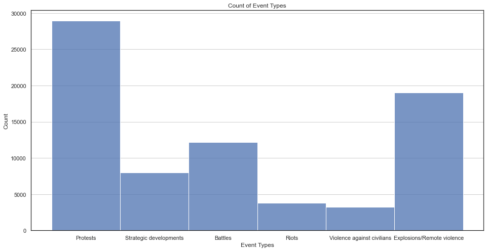

```python
# distribution of event types
sns.set(style = "white")

# figure size in inches
rcParams['figure.figsize'] = 16, 8

event_type = sns.histplot(x = 'event_type', data = Events)
event_type.set_title('Count of Event Types')
event_type.set_xlabel('Event Types');
event_type.grid(axis = 'y')
```

We also want to take a look at the total number of events per country.

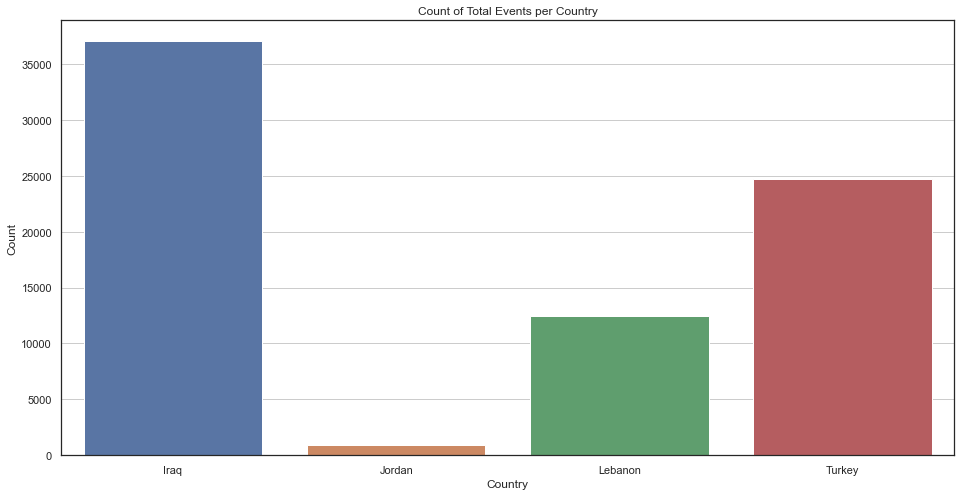

```python
# visualizing total events per country
sns.set(style = "white")

# figure size in inches
rcParams['figure.figsize'] = 16, 8

total_event_type = sns.barplot(x = 'country', y = 'event_counts', data = total_events)
total_event_type.set_title('Count of Total Events per Country')
total_event_type.set_xlabel('Country')
total_event_type.set_ylabel('Count')
total_event_type.grid(axis = 'y')
```

Here, we can see that among all of the events, protests are the most common followed by explosions/remote violence with violence against civilians having the least occurrences.

Iraq can be seen to have the most events followed by Turkey and Lebanon. The large prevalences of these countries in terms of conflicts show that fleeing Syria, the refugees may still encounter civil unrest and conflicts in their new host countries.

After identifying the distribution of event types, we will then break down these numbers based on each country of interest.

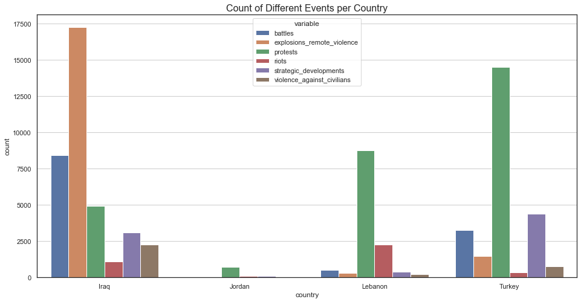

```python
# distribution of event types per country
count_event_long = pd.melt(count_event, id_vars='country', value_vars=['battles', 'explosions_remote_violence', 'protests', 'riots', 'strategic_developments', 'violence_against_civilians'])

sns.set(style = "white")

# figure size in inches
rcParams['figure.figsize'] = 16, 8

type_of_event = sns.barplot(x = 'country', y = 'value', hue = 'variable', data = count_event_long)
type_of_event.set_title('Count of Different Events per Country', fontsize=16)
type_of_event.set_ylabel('count')
type_of_event.grid(axis = 'y')
```

After looking at the types of conflicted events, we will then explore the number of fatalities between the countries of our datasets within the timeframe we specified, which is between January 1, 2016 and April 22, 2022. This will allow us to discover relationships between event types and the number of fatalities.

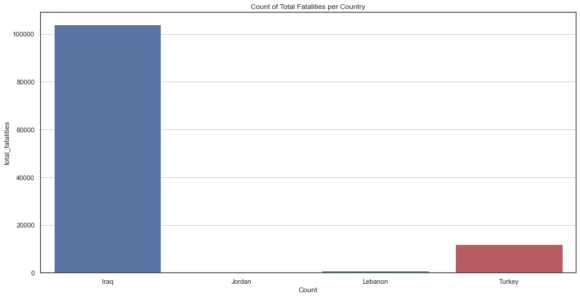

```python
# visualizing total fatalities per country
sns.set(style = "white")

# figure size in inches
rcParams['figure.figsize'] = 16, 8

total_fatality = sns.barplot(x = 'country', y = 'total_fatalities', data = total_fatalities)
total_fatality.set_title('Count of Total Fatalities per Country')
total_fatality.set_xlabel('Country')
total_fatality.set_xlabel('Count')
total_fatality.grid(axis = 'y')
```

In this case, Iraq has the highest number of fatalities compared to other countries in our datasets. While the number of fatalities is not as substantial as Iraq's, there is still a considerable amount of fatalities in Turkey and Lebanon. This indicates that there are also conflicts taking place in countries bordering Syria, meaning that asylum seekers are not completely free from conflict when migrating to neighboring countries.

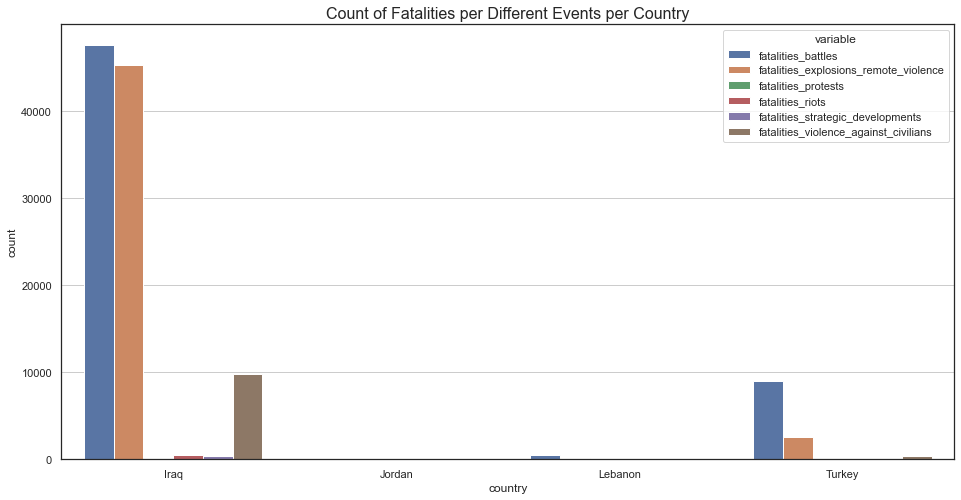

```python
# distribution of fatalities per event types per country
fatality_event_long = pd.melt(fatality_event, id_vars='country', value_vars=['fatalities_battles', 'fatalities_explosions_remote_violence', 'fatalities_protests', 'fatalities_riots', 'fatalities_strategic_developments', 'fatalities_violence_against_civilians'])

# distribution of event types
sns.set(style = "white")

# figure size in inches
rcParams['figure.figsize'] = 16, 8

type_of_event_fatalities = sns.barplot(x = 'country', y = 'value', hue = 'variable', data = fatality_event_long)
type_of_event_fatalities.set_title('Count of Fatalities per Different Events per Country', fontsize=16)
type_of_event_fatalities.set_ylabel('count')
type_of_event_fatalities.grid(axis = 'y')
```

Similar to the the event occurrences, Iraq also has more fatalities per event. They are followed by Turkey and then Lebanon.

We then take a look at the refugee population per country.

```python
# number of Syrian refugees per country
count_refugees[['country','count_refugees']]
```

|  | country | count_refugees |
| --- | --- | --- |
| 0 | Turkey | 3763211 |
| 1 | Lebanon | 839086 |
| 2 | Jordan | 674458 |
| 3 | Iraq | 258965 |

[figure not shown]

```python
# number of persons of concern by country of asylum
indiv = sns.barplot(x = 'country', y = 'count_refugees', data = count_refugees)
indiv.set_title('Number of Persons of Concern by Country of Asylum');
indiv.set_xlabel('Country');
indiv.set_ylabel('Number of Persons of Concern')
indiv.set_yticklabels(['0', '50,000', '100,000', '150,000', '200,000', '250,000', '300,000', '350,000'])
indiv.grid(axis = 'y')
```

The barplot shows that Turkey consists of the greatest number of Syrian refugees, accounting about 68 percent of the total Syrian refugee population among the neighboring countries. This implies that the majority of Syrian refugees are more likely to choose Turkey as the destination of asylum.

We will also take a look into the age and gender demographics of the Syrian refugees.

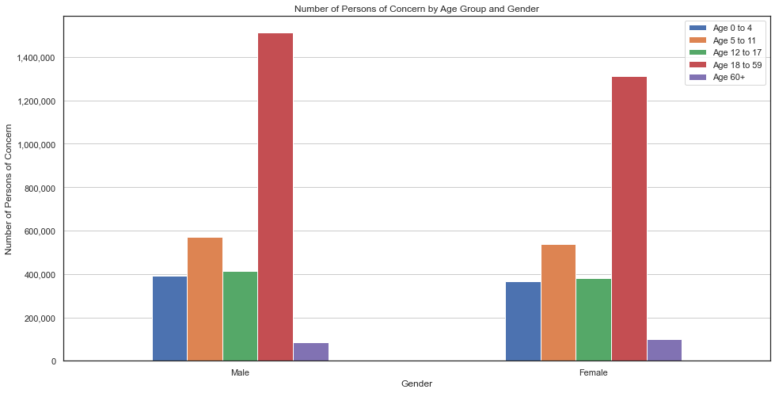

```python
# number of persons of concern by age group and gender
a_g = age_gender_rearranged.plot(x = "Gender", y = ["Age 0 to 4", "Age 5 to 11", "Age 12 to 17", "Age 18 to 59", "Age 60+"], kind = "bar")
a_g.set_title('Number of Persons of Concern by Age Group and Gender');
a_g.set_ylabel('Number of Persons of Concern')
a_g.set_xticklabels(['Male', 'Female'], rotation = 0);
a_g.set_yticklabels(['0', '200,000', '400,000', '600,000', '800,000', '1,000,000', '1,200,000', '1,400,000'])
a_g.grid(axis = 'y')
```

Unsurprisingly, Syrian refugees ages between 18 and 59 consisted the highest number in both genders due to the large age range being grouped here. However, if we look specifically at age groups below 18 and combine the three age groups, you can notice that it is almost just as much as the "18 to 59" age group, accounting about 46 and 48 percent of the total refugee population in both males and females respectively. This signifies that children and teenagers make up a significant portion of the refugees, almost half of the refugee population.

Another factor that we wanted to consider when looking at the factors that contributed to choosing a host location was the individual populations of each host country

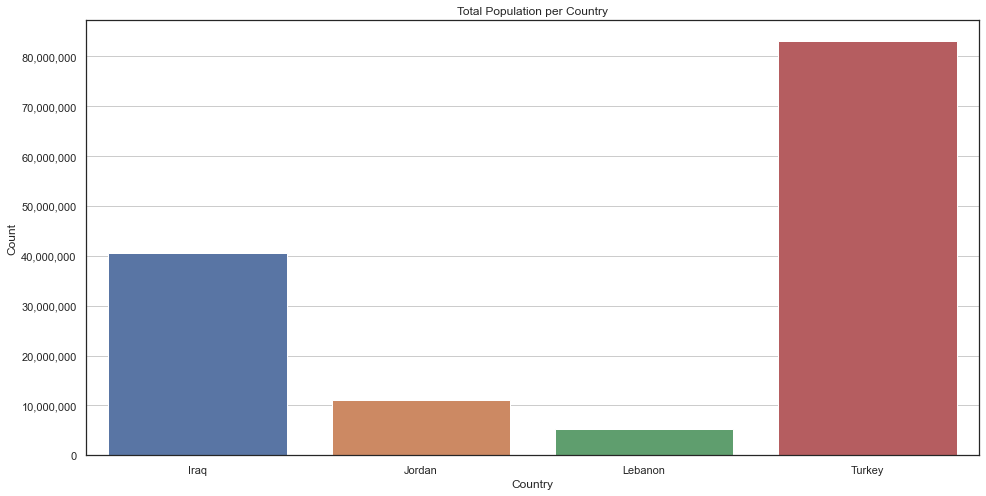

```python
# visualizing total population per country
sns.set(style = "white")

# figure size in inches
rcParams['figure.figsize'] = 16, 8

country_population = sns.barplot(x = 'country', y = 'population', data = pop_stats)
country_population.set_title('Total Population per Country')
country_population.set_xlabel('Country')
country_population.set_ylabel('Count')
country_population.set_yticklabels(['0', '10,000,000', '20,000,000', '30,000,000', '40,000,000', '50,000,000', '60,000,000', '70,000,000', '80,000,000', '90,000,000'])
country_population.grid(axis = 'y')
```

Here we see that the countries with the largest populations are Turkey, Iraq, Jordan, followed by Lebanon. Turkey is seen to have more than double Iraq's population which is the second largest country in terms of population.

To narrow it down even more, we decided to take a look at the distribution of males and females within each country.

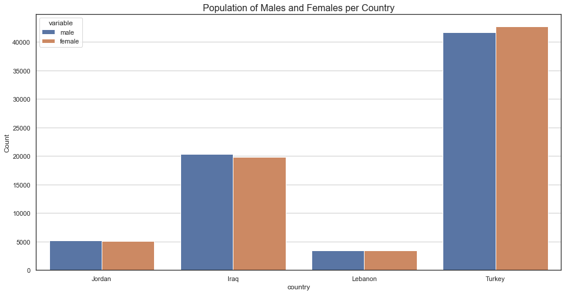

```python
# distribution of males and females per country
male_female = reduce(lambda  left,right: pd.merge(left,right,on=['country'],
                                            how='outer'), [male, female])
male_female = pd.melt(male_female, id_vars='country', value_vars=['male', 'female'])

# distribution of event types
sns.set(style = "white")

# figure size in inches
rcParams['figure.figsize'] = 16, 8

male_female_visual = sns.barplot(x = 'country', y = 'value', hue = 'variable', data = male_female)
male_female_visual.set_title('Population of Males and Females per Country', fontsize=16)
male_female_visual.set_ylabel('Count')
male_female_visual.grid(axis = 'y')
```

Here we see that in Jordan and Iraq, their populations have more males than females whereas in Turkey, there are more females than males and then in Lebanon, it is approximately equal.

We then chose to look at the population density of each country to see if there were any significant differences between the areas bordering Syria.

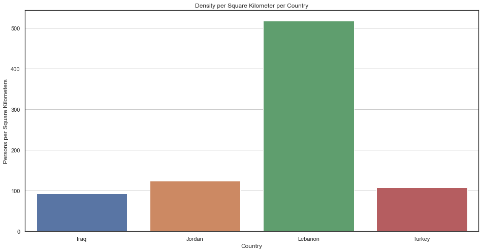

```python
# visualizing people per square kilometer per country
sns.set(style = "white")

# figure size in inches
rcParams['figure.figsize'] = 16, 8

density_per_sq_km = sns.barplot(x = 'country', y = 'density_per_sq_km', data = pop_stats)
density_per_sq_km.set_title('Density per Square Kilometer per Country')
density_per_sq_km.set_xlabel('Country')
density_per_sq_km.set_ylabel('Persons per Square Kilometers')
density_per_sq_km.grid(axis = 'y')
```

The amount of people per square kilometer in Lebanon is vastly larger than any of the other countries. Being more than double that of Jordan, the country with the second highest population density, this may be a factor in where the refugees decide to settle.

We also decided to take a look at the health outcomes of the different countries including life expectancy and mortality rate of those under 5 years of age.

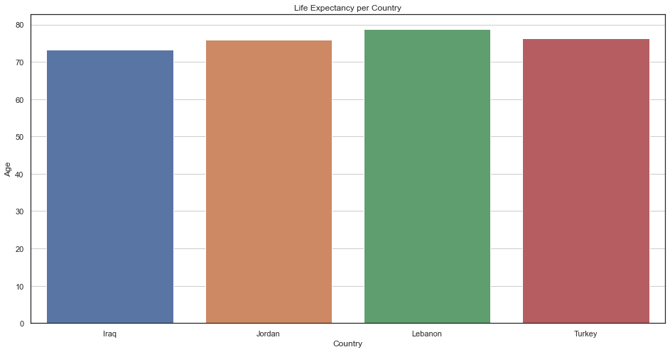

```python
# visualizing life expectancy per country
sns.set(style = "white")

# figure size in inches
rcParams['figure.figsize'] = 16, 8

life_expectancy = sns.barplot(x = 'country', y = 'life_expectancy', data = pop_stats)
life_expectancy.set_title('Life Expectancy per Country')
life_expectancy.set_xlabel('Country')
life_expectancy.set_ylabel('Age')
life_expectancy.grid(axis = 'y')
```

Here we can see that all of the different countries have life expectancies hovering around the 70-80 years old area.

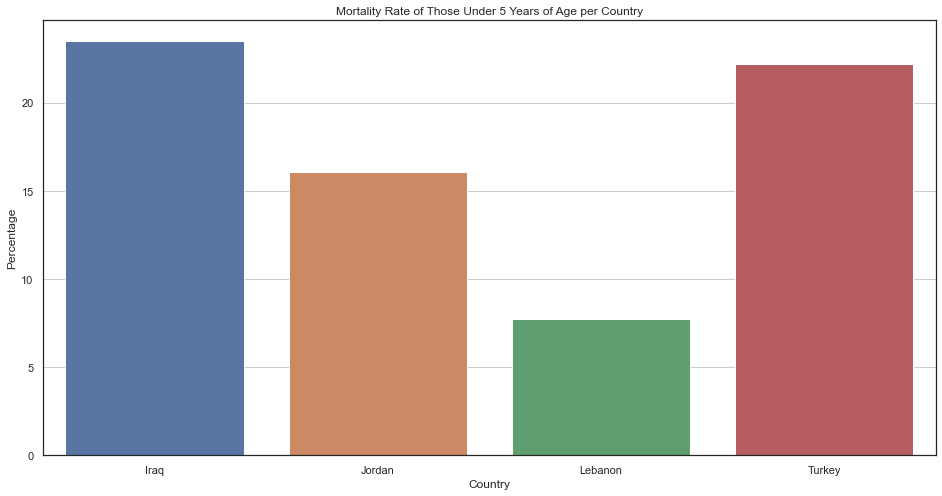

```python
# visualizing mortality rate of those under 5 years of age
sns.set(style = "white")

# figure size in inches
rcParams['figure.figsize'] = 16, 8

under_5_mortality_rate = sns.barplot(x = 'country', y = 'under_5_mortality_rate', data = pop_stats)
under_5_mortality_rate.set_title('Mortality Rate of Those Under 5 Years of Age per Country')
under_5_mortality_rate.set_xlabel('Country')
under_5_mortality_rate.set_ylabel('Percentage')
under_5_mortality_rate.grid(axis = 'y')
```

We also took a look at the economic aspects of each country such as annual growth rate, GDP, and unemployment and inflation rates.

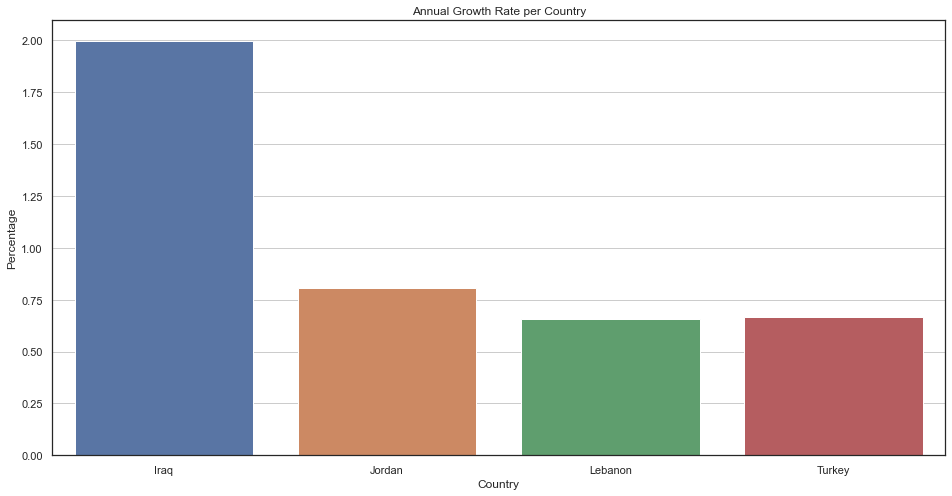

```python
# visualizing annual growth rate per country
sns.set(style = "white")

# figure size in inches
rcParams['figure.figsize'] = 16, 8

annual_growth_rate = sns.barplot(x = 'country', y = 'annual_growth_rate', data = pop_stats)
annual_growth_rate.set_title('Annual Growth Rate per Country')
annual_growth_rate.set_xlabel('Country')
annual_growth_rate.set_ylabel('Percentage')
annual_growth_rate.grid(axis = 'y')
```

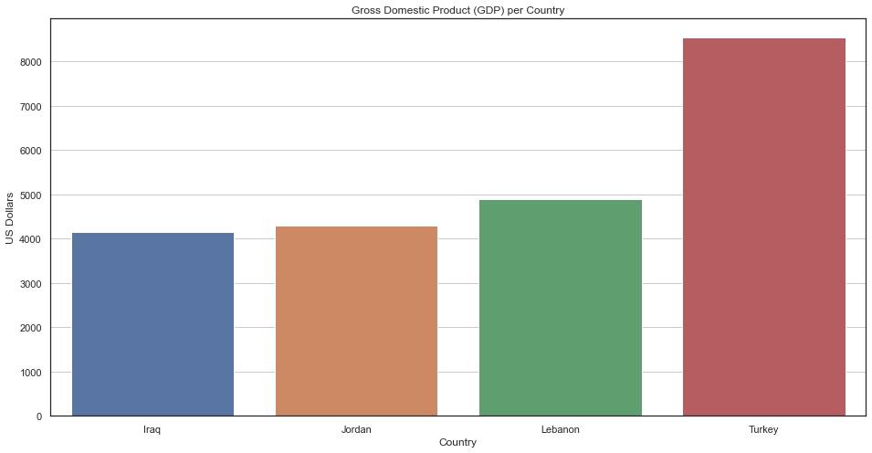

```python
# visualizing gross domestic product (GDP) per country
sns.set(style = "white")

# figure size in inches
rcParams['figure.figsize'] = 16, 8

gdp_visual = sns.barplot(x = 'country', y = 'gdp', data = gdp)
gdp_visual.set_title('Gross Domestic Product (GDP) per Country')
gdp_visual.set_xlabel('Country')
gdp_visual.set_ylabel('US Dollars')
gdp_visual.grid(axis = 'y')
```

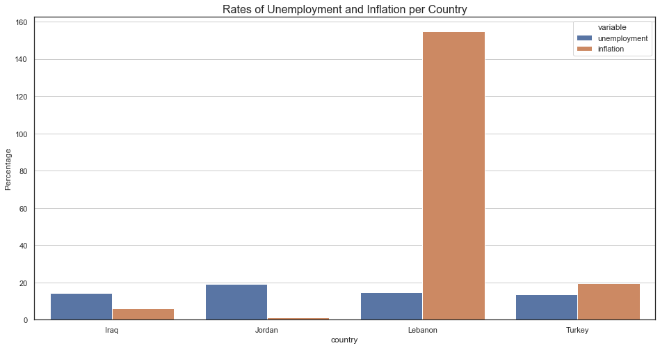

```python
# visualizing unemployment and inflation rates per country

unemployment_inflation = reduce(lambda  left,right: pd.merge(left,right,on=['country'],
                                            how='outer'), [unemployment, inflation])
unemployment_inflation = pd.melt(unemployment_inflation, id_vars='country', value_vars=['unemployment', 'inflation'])

sns.set(style = "white")

# figure size in inches
rcParams['figure.figsize'] = 16, 8

unemployment_inflation_visual = sns.barplot(x = 'country', y = 'value', hue = 'variable', data = unemployment_inflation)
unemployment_inflation_visual.set_title('Rates of Unemployment and Inflation per Country', fontsize=16)
unemployment_inflation_visual.set_ylabel('Percentage')
unemployment_inflation_visual.grid(axis = 'y')
```

When looking at the annual growth rate, Iraq has the highest rates followed by Jordan, and then Lebanon and Turkey. GDP, on the other hand, from largest to smallest is Turkey, Lebanon, Jordan, and then Iraq.

In terms of unemployment, all countries have rates above 10% and less than 20%. For inflation, however, Lebanon has the highest rates of over 150% followed by Turkey at slightly under 20%, then Iraq at less than 10% and then Jordan.

We also took a look at relatively safety measures such as kidnapping and homicides.

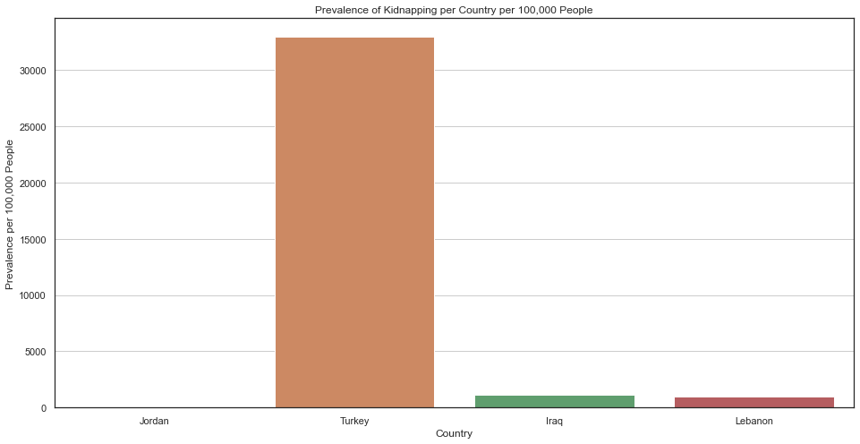

```python
# visualizing prevalence of kidnappings per country
sns.set(style = "white")

# figure size in inches
rcParams['figure.figsize'] = 16, 8

kidnapping_visual = sns.barplot(x = 'country', y = 'kidnapping', data = kidnapping)
kidnapping_visual.set_title('Prevalence of Kidnapping per Country per 100,000 People')
kidnapping_visual.set_xlabel('Country')
kidnapping_visual.set_ylabel('Prevalence per 100,000 People')
kidnapping_visual.grid(axis = 'y')
```

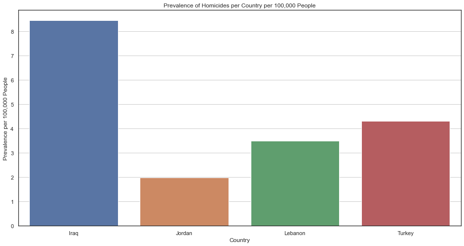

```python
# visualizing prevalence of homicides per country
sns.set(style = "white")

# figure size in inches
rcParams['figure.figsize'] = 16, 8

homicide_visual = sns.barplot(x = 'country', y = 'homicides', data = homicides)
homicide_visual.set_title('Prevalence of Homicides per Country per 100,000 People')
homicide_visual.set_xlabel('Country')
homicide_visual.set_ylabel('Prevalence per 100,000 People')
homicide_visual.grid(axis = 'y')
```

In terms of kidnapping, Turkey has significantly higher levels of kidnapping that the other countries in terms of total numbers. For intentional homicides, Iraq has the highest counts followed by Turkey, Lebanon, than Jordan.

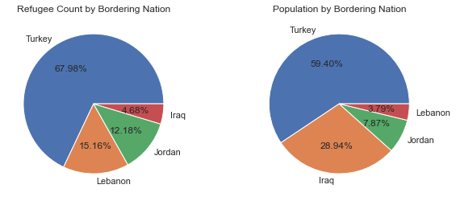

```python
fig, (ax1,ax2) = plt.subplots(1,2, figsize=(10,4))

refugee_count = feature.groupby('country')['count_refugees'].sum().sort_values(ascending=False)

x = []
y = []

for count in refugee_count.index:
    x.append(count)
    y.append(refugee_count[count])

ax1.set_title("Refugee Count by Bordering Nation")
ax1.pie(y, labels=x, autopct='%1.2f%%')

pop_count = feature.groupby('country')['population'].sum().sort_values(ascending=False)

x = []
y = []

for count in pop_count.index:
    x.append(count)
    y.append(pop_count[count])

ax2.set_title("Population by Bordering Nation")
ax2.pie(y, labels=x, autopct='%1.2f%%')

plt.show()
```

A quick side by side comparison between population and excepted refugee count, shows us that Iraq as a nation has taken a disproportionately low amount of refugees. We plan on digging into the migration trends in the next part.

```python
feature
```

|  | country | event_counts | total_fatalities | battles | explosions_remote_violence | protests | riots | strategic_developments | violence_against_civilians | fatalities_battles | ... | density_per_sq_km | life_expectancy | under_5_mortality_rate | gdp | kidnapping | homicides | unemployment | inflation | male | female |
| --- | --- | --- | --- | --- | --- | --- | --- | --- | --- | --- | --- | --- | --- | --- | --- | --- | --- | --- | --- | --- | --- |
| 0 | Iraq | 37053 | 103869 | 8413 | 17263 | 4936 | 1074 | 3091 | 2276 | 47616 | ... | 92.5 | 73.18 | 23.49 | 4157.0 | 1119.0 | 8.457193 | 14.192000 | 6.041865 | 20357 | 19863 |
| 1 | Jordan | 940 | 119 | 17 | 21 | 726 | 89 | 76 | 11 | 61 | ... | 123.9 | 76.01 | 16.07 | 4283.0 | 34.0 | 1.990120 | 19.252001 | 1.346094 | 5166 | 5035 |
| 2 | Lebanon | 12442 | 797 | 502 | 295 | 8765 | 2265 | 403 | 212 | 534 | ... | 517.8 | 78.76 | 7.75 | 4891.0 | 1005.0 | 3.503310 | 14.488000 | 154.756096 | 3436 | 3389 |
| 3 | Turkey | 24726 | 11917 | 3268 | 1470 | 14511 | 356 | 4381 | 740 | 9000 | ... | 107.9 | 76.21 | 22.21 | 8538.0 | 32953.0 | 4.308044 | 13.386000 | 19.596493 | 41638 | 42702 |

4 rows × 29 columns

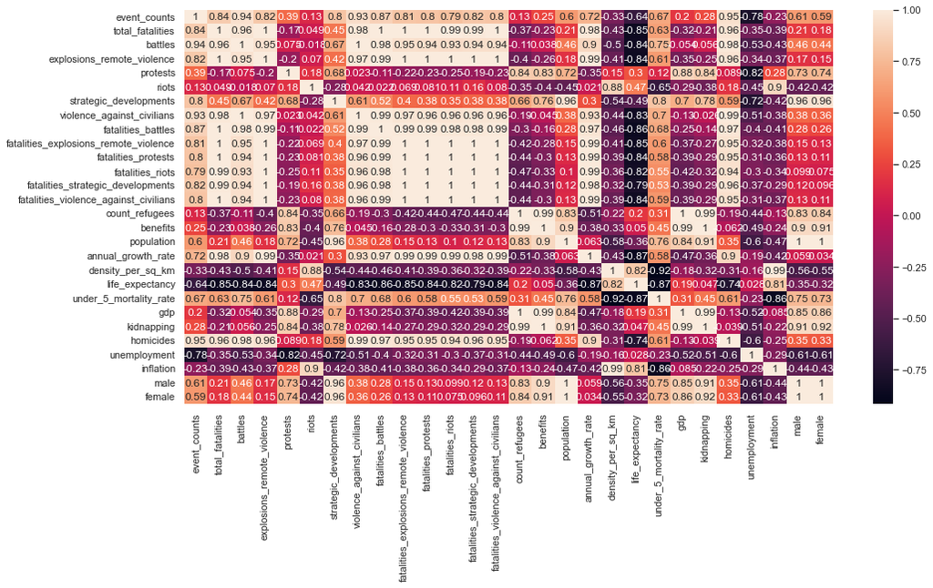

```python
corrMatrix = feature.corr()
sns.heatmap(corrMatrix, annot=True)
plt.show()
```

From the correlation matrix, we are able to see that some features such as violence_against_civilians and fatalities_battles are simmilarly correlated with other features on the dataset so we will remove these features and keep one. The criteria we will use for dropping columns will be based on the correlations with different variables varying by 0.05 among multiple measures.

```python
feature = feature.drop(columns = ["explosions_remote_violence",
                                   "violence_against_civilians",
                                   "fatalities_battles",
                                   "fatalities_explosions_remote_violence",
                                   "fatalities_protests",
                                   "fatalities_riots",
                                   "fatalities_strategic_developments",
                                   "fatalities_violence_against_civilians",
                                   "male"])
```

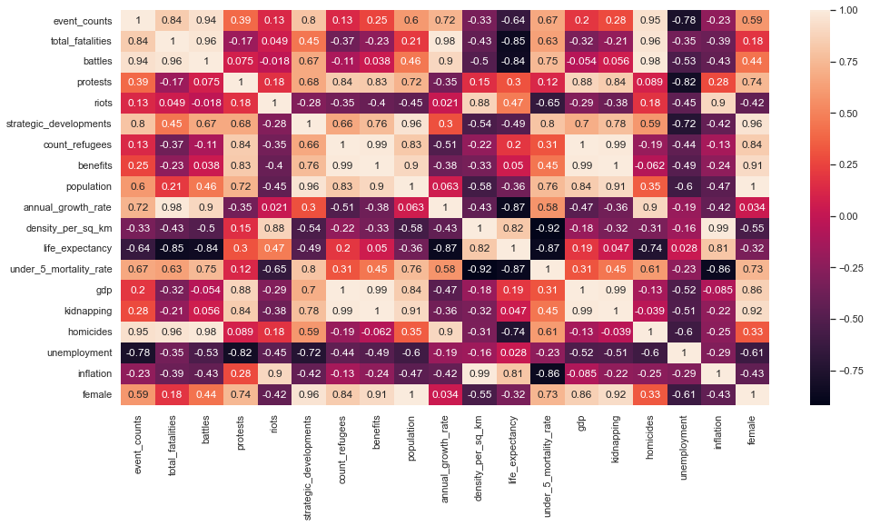

```python
corrMatrix = feature.corr()
sns.heatmap(corrMatrix, annot=True)
plt.show()
```

Based on the generated correlation matrix, we should look into the relationship between our count_refugee variable and other measures having a correlation close to the absolute value of 1 to show which ones highly correlate, whether positive or negative, with the number of refugees. In this instance, we would say that protests, benefits, population, gdp, kidnapping, and female are among the features that best correlate with refugees who flee to these regions.

[figure not shown]

```python
# Chart out the Refugees over time for each bordering nation
sns.lineplot(x = refugees['Year'], y = refugees['Refugees under UNHCR\'s mandate'], hue=refugees['Country of asylum'])

# Set the legend to indicate status as UNHCR Refugees
plt.legend(title='UNHCR Refugees', labels=['Iraq', 'Lebanon', 'Jordan', 'Turkey'])
plt.ylabel('Total Refugee Count')

# Denote a second axis to graph on and do the same for the Asylum Seekers
ax2 = plt.twinx()

sns.lineplot(x = refugees['Year'], y = refugees['Asylum-seekers'], hue=refugees['Country of asylum'], palette='rocket',ax=ax2, legend=False)

# Add another Legend denoting Asylum Seekers
plt.legend(title='Asylum Seekers', labels=['Iraq', 'Lebanon', 'Jordan', 'Turkey'])
plt.show()
```

At the start of the Syrian Civil War, we see an explosion of asylum seekers flowing into these nations . A few years into the domestic conflict, however, over time, asylum seekers were replaced with official UN status as refugees. Under these changes, the net ifnlux of refugee/asylum seekers plateau.

```python
# Turkey model

model = sklearn.linear_model.LinearRegression()

refugees1 = refugees[refugees["Country of asylum"] == "Turkey"]

X = refugees1[['Year']]
y = refugees1['Refugees under UNHCR\'s mandate']

X_train, X_test, y_train, y_test = train_test_split(X, y, shuffle=True, train_size=0.3)

model.fit(X_train, y_train)

predictions = model.predict(X_test)
r2 = r2_score(y_test, predictions)
rmse = mean_squared_error(y_test, predictions, squared=False)

print('The r2 is: ', r2)
print('The rmse is: ', rmse)
```

```
The r2 is:  0.40016591295337944
The rmse is:  1165878.0129332263
```

```python
# Lebanon model

model = sklearn.linear_model.LinearRegression()

refugees1 = refugees[refugees["Country of asylum"] == "Lebanon"]

X = refugees1[['Year']]
y = refugees1['Refugees under UNHCR\'s mandate']

X_train, X_test, y_train, y_test = train_test_split(X, y, shuffle=True, train_size=0.3)

model.fit(X_train, y_train)

predictions = model.predict(X_test)
r2 = r2_score(y_test, predictions)
rmse = mean_squared_error(y_test, predictions, squared=False)

print('The r2 is: ', r2)
print('The rmse is: ', rmse)
```

```
The r2 is:  0.14673534801489074
The rmse is:  381192.90630753286
```

```python
# Iraq model

model = sklearn.linear_model.LinearRegression()

refugees1 = refugees[refugees["Country of asylum"] == "Iraq"]

X = refugees1[['Year']]
y = refugees1['Refugees under UNHCR\'s mandate']

X_train, X_test, y_train, y_test = train_test_split(X, y, shuffle=True, train_size=0.3)

model.fit(X_train, y_train)

predictions = model.predict(X_test)
r2 = r2_score(y_test, predictions)
rmse = mean_squared_error(y_test, predictions, squared=False)

print('The r2 is: ', r2)
print('The rmse is: ', rmse)
```

```
The r2 is:  -0.29386048818138755
The rmse is:  120238.48402978721
```

```python
# Jordan model

model = sklearn.linear_model.LinearRegression()

refugees1 = refugees[refugees["Country of asylum"] == "Jordan"]

X = refugees1[['Year']]
y = refugees1['Refugees under UNHCR\'s mandate']

X_train, X_test, y_train, y_test = train_test_split(X, y, shuffle=True, train_size=0.3)

model.fit(X_train, y_train)

predictions = model.predict(X_test)
r2 = r2_score(y_test, predictions)
rmse = mean_squared_error(y_test, predictions, squared=False)

print('The r2 is: ', r2)
print('The rmse is: ', rmse)
```

```
The r2 is:  0.5842201074161127
The rmse is:  174001.90747041968
```

# Ethics & Privacy

Our project is being done purely for academic purposes, and all of the datasets that we pull from are publicly available. Additionally, the entries from these datasets are unmodified, and are analyzed directly from the CSV files. We would also like to address that while we attempted to include as many factors that could potentially affect the resettlement relocation of Syrian refugees, we may be missing other factors that could have higher predictive values. This could have an unintended consequence of someone misusing our findings as they may not be completely comprehensive. Furthermore, these datasets are pulled from websites including UNICEF, UNHCR, and ACLED, in which the data should be confirmed before making any declarative statements or other assumptions as there may be inconsistencies.

Additionally, there are also privacy concerns for those who view our project and want to access the datasets that we used. Some of these sites may collect personal information such as names, postal address, email addresses, telephone numbers, social media names, contact preferences, gender, date of birth, etc. While some sites may collect standard information such as an IP address or computer ID, others require the user to sign up and provide other details.

# Conclusion & Discussion

There are several immediate trends that stand out when analyzing the immigration data provided by the UN. Since topics like immigration and asylum seeking are such intensely political issues, we decided to look into any potential external social pressures that might impact the rate refugees are accepted.

A consistent theme across all of the analyzed nations is that asylum seeking peoples spiked in the early years of the conflict. This growth then tapers to zero for each nation as time approaches 2022. Furthermore, UN mandated refugees started slowly and grew into the only method of migration by 2015. It is the opinion of the group that this shift was caused by initial lack of governmental programs to facilitate refugees, and as time went on programs were set in place to control inflows and uniformly classify Syrian migrants.